# RSY: MC1

Studiengang Data Science (HS2022), FHNW

Jan Zwicky und Gabriel Torres

Letzte Aktualisierungen: December 08, 2022

# 1 Pakete laden und Daten einlesen

## 1.1 Pakete laden

```r
# Pakete für Data Wrangling und Visualisierung
library(tidyverse)
library(rsample)
library(hablar)
library(gridExtra)
library(fastDummies)
library(stats)

# Pakete für das HTML
library(bookdown)
library(knitr)

# Recommenderlab und ähnlich
library(recommenderlab)
library(vegan)
library(coop)
```

## 1.2 Konfiguration

```r
# Konfiguration der Pakete
knitr::opts_chunk$set(fit.align = "left", cache = TRUE, warning = FALSE, message = FALSE)
```

## 1.3 Daten einlesen

```r
# Einlesen der CSV-Dateien und erstellen der samples
movies1 <- read.csv("ml-latest-small/movies.csv", sep = ",")
links1 <- read.csv("ml-latest-small/links.csv", sep = ",")
ratings1 <- read.csv("ml-latest-small/ratings.csv", sep = ",")
tags1 <- read.csv("ml-latest-small/tags.csv", sep = ",")

# Sample von 70%
set.seed(69)
movies2 <- movies1 %>% slice_sample(prop = 0.7)
links2 <- subset(links1, movieId %in% movies2$movieId)
ratings2 <- subset(ratings1, movieId %in% movies2$movieId) %>% slice_sample(prop = 0.7)
tags2 <- subset(tags1, movieId %in% movies2$movieId)

# 2ter Sample von 70%
set.seed(100)
movies1 <- movies1 %>% slice_sample(prop = 0.7)
links1 <- subset(links1, movieId %in% movies1$movieId)
ratings1 <- subset(ratings1, movieId %in% movies1$movieId) %>% slice_sample(prop = 0.7)
tags1 <- subset(tags1, movieId %in% movies1$movieId)
```

# 2 EDA

## 2.1 Welches sind die am häufigsten geschauten Filme?

### 2.1.1 Sample 1

```r
kable(left_join(movies1, ratings1, "movieId") %>%
  group_by(title, movieId, genres) %>%
  summarise(count = n()) %>%
  arrange(desc(count)) %>%
  head(3))
```

| title | movieId | genres | count |
| --- | --- | --- | --- |
| Forrest Gump (1994) | 356 | Comedy\|Drama\|Romance\|War | 234 |
| Pulp Fiction (1994) | 296 | Comedy\|Crime\|Drama\|Thriller | 200 |
| Star Wars: Episode IV - A New Hope (1977) | 260 | Action\|Adventure\|Sci-Fi | 181 |

### 2.1.2 Sample 2

```r
kable(left_join(movies2, ratings2, "movieId") %>%
  group_by(title, movieId, genres) %>%
  summarise(count = n()) %>%
  arrange(desc(count)) %>%
  head(3))
```

| title | movieId | genres | count |
| --- | --- | --- | --- |
| Shawshank Redemption, The (1994) | 318 | Crime\|Drama | 228 |
| Pulp Fiction (1994) | 296 | Comedy\|Crime\|Drama\|Thriller | 219 |
| Star Wars: Episode IV - A New Hope (1977) | 260 | Action\|Adventure\|Sci-Fi | 182 |

**Beschreibung:** In den beiden Outputs haben wir die Aufzählung der 3 meist bewerteten Filme, bei dem die Spalte ‘count’ die Anzahl Bewertungen ist. Die Top 3 Filme wurden bei beiden Datensätzen etwa 180 bis 240 mal bewertet. Pulp Fiction und Star Wars kommen in beiden Datensätzen in unterschiedlicher Anzahl vor.

**Schlussfolgerung:** Wir können nicht bestimmen, wie oft ein Film geschaut wurde, da es zu dieser Information keine Daten gibt. Als alternative definieren wir, dass geschaut und bewertet gleichgestellt wird.

## 2.2 Welches sind die am häufigsten geschauten Genres?

### 2.2.1 Sample 1

```r
genres_sep1 <- movies1 %>%
  separate_rows(genres, sep = "\\|", convert = FALSE) %>%
  replace(. == "", "no genres listed")

kable(genres_sep1 %>%
  right_join(ratings1, "movieId") %>%
  group_by(genres) %>%
  summarise(count = n()) %>%
  arrange(desc(count)) %>%
  head(3))
```

| genres | count |
| --- | --- |
| Drama | 20803 |
| Comedy | 19432 |
| Action | 14383 |

### 2.2.2 Sample 2

```r
genres_sep2 <- movies2 %>%
  separate_rows(genres, sep = "\\|", convert = FALSE) %>%
  replace(. == "", "no genres listed")

kable(genres_sep2 %>%
  right_join(ratings2, "movieId") %>%
  group_by(genres) %>%
  summarise(count = n()) %>%
  arrange(desc(count)) %>%
  head(3))
```

| genres | count |
| --- | --- |
| Drama | 20230 |
| Comedy | 20019 |
| Action | 14118 |

**Beschreibung:** In beiden Outputs haben wir die meist bewerteten Filmgenres, bei dem die Spalte ‘count’ signalisiert, bei wie vielen Filmbewertungen der bewertete Film dieses Genre beinhaltet. Der Outputs ist bei beiden Datensätzen sehr ähnlich.

**Schlussfolgerung:** Die am meist geschauten/bewerteten Genres sind Drama, Comedy und Action.

## 2.3 Wie verteilen sich die Kundenratings gesamthaft?

### 2.3.1 Sample 1

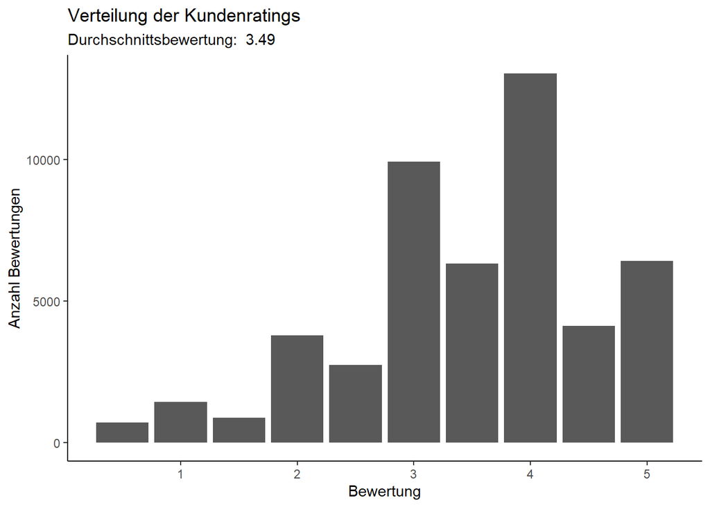

```r
# Gesamthaft
ggplot(ratings1, aes(rating)) +
  geom_bar() +
  labs(
    title = "Verteilung der Kundenratings",
    x = "Bewertung",
    y = "Anzahl Bewertungen",
    subtitle = paste("Durchschnittsbewertung: ", round(mean(ratings1$rating),2))
  ) +
  theme_classic() +
  theme(legend.position = "none")
```

### 2.3.2 Sample 2

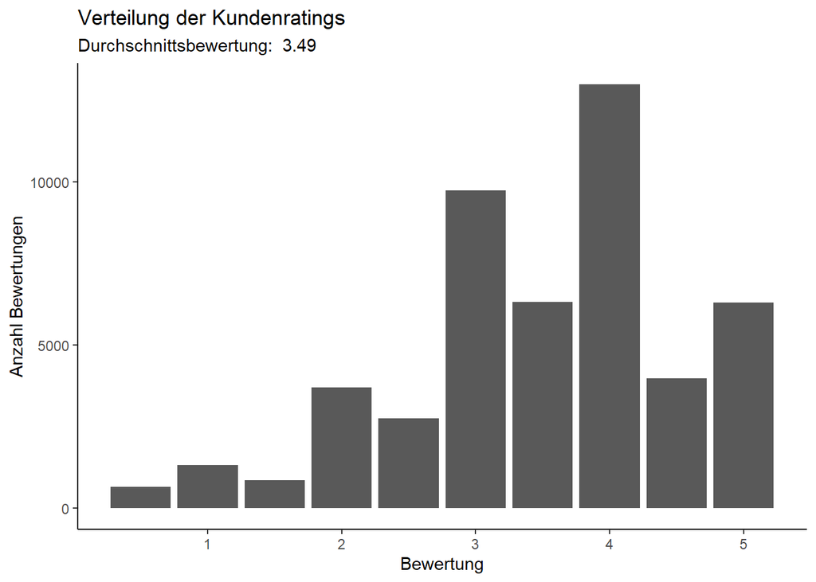

```r
# Gesamthaft
ggplot(ratings2, aes(rating)) +
  geom_bar() +
  labs(
    title = "Verteilung der Kundenratings",
    x = "Bewertung",
    y = "Anzahl Bewertungen",
    subtitle = paste("Durchschnittsbewertung: ", round(mean(ratings2$rating),2))
  ) +
  theme_classic() +
  theme(legend.position = "none")
```

**Beschreibung:** In diesen Plots wird die Verteilung der Kundenratings visualisiert.

**Schlussfolgerung:** Die Kundenratings sind nicht ganz normalverteilt, aber nahe. Die meisten Bewertungen sind im Bereich der natürlichen Zahlen, wenige Bewertungen sind ein Wert zwischen zwei dieser Zahlen. Öfters enthält eine Bewertung den Wert 4. Der Durchschnitt aller Bewertungen liegt bei etwa 3,5.

## 2.4 Wie verteilen sich die Kundenratings nach Genres?

### 2.4.1 Sample 1

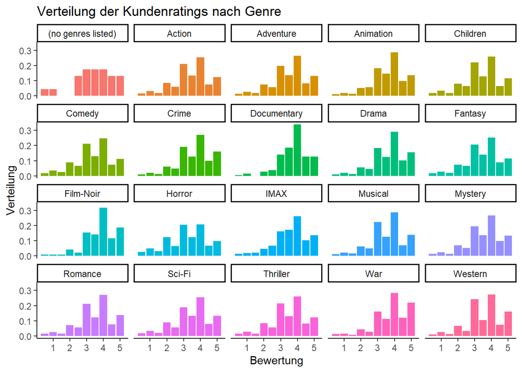

```r
# Nach Genres
genres_sep_ratings1 <- genres_sep1 %>%
  right_join(ratings1, "movieId")
ggplot(genres_sep_ratings1, aes(x = rating, fill = genres)) +
  geom_bar(aes(y = ..prop.., group = 1)) +
  facet_wrap(~genres) +
  labs(
    title = "Verteilung der Kundenratings nach Genre",
    x = "Bewertung",
    y = "Verteilung",
  ) +
  theme_classic() +
  theme(legend.position = "none")
```

### 2.4.2 Sample 2

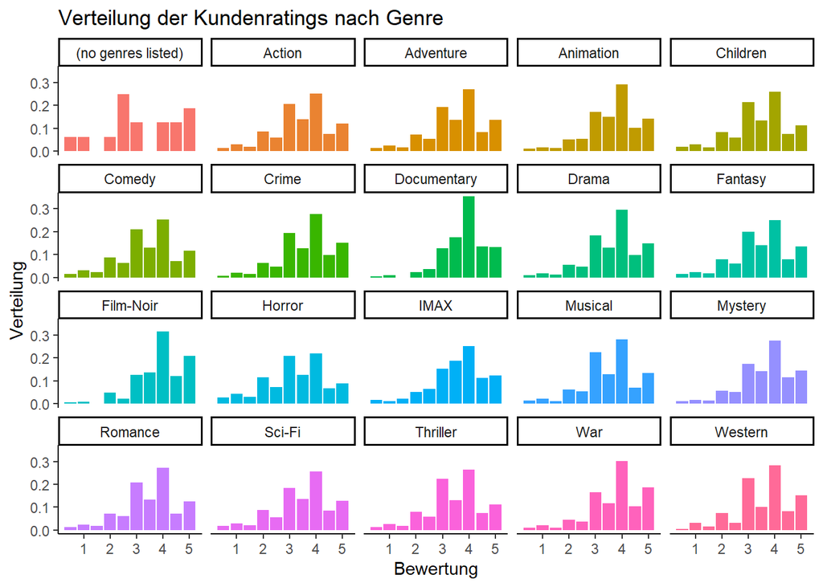

```r
# Nach Genres
genres_sep_ratings2 <- genres_sep2 %>%
  right_join(ratings2, "movieId")
ggplot(genres_sep_ratings2, aes(x = rating, fill = genres)) +
  geom_bar(aes(y = ..prop.., group = 1)) +
  facet_wrap(~genres) +
  labs(
    title = "Verteilung der Kundenratings nach Genre",
    x = "Bewertung",
    y = "Verteilung",
  ) +
  theme_classic() +
  theme(legend.position = "none")
```

**Beschreibung:** Diese Plots sind ähnlich wie die letzten zwei. Hier wird die Verteilung der Kundenratings **nach Kategorie** visualisiert.

**Schlussfolgerung:** Die Verteilung der Kundenratings ähneln sich bei vielen Kategorien der Verteilung der Gesamtmenge. Jedoch mit einigen Ausnahmen: Dokumentarfilme haben zum Beispiel überdurchschnittlich viele Bewertungen mit dem Wert 4 und unterdurchschnittlich wenig Bewertungen mit dem Wert 3 und 5. Man könnte sagen, dass Dokumentarfilme sehr konstante Ratings haben.

## 2.5 Wie verteilen sich die mittleren Kundenratings pro Film?

### 2.5.1 Alle Daten Sample 1

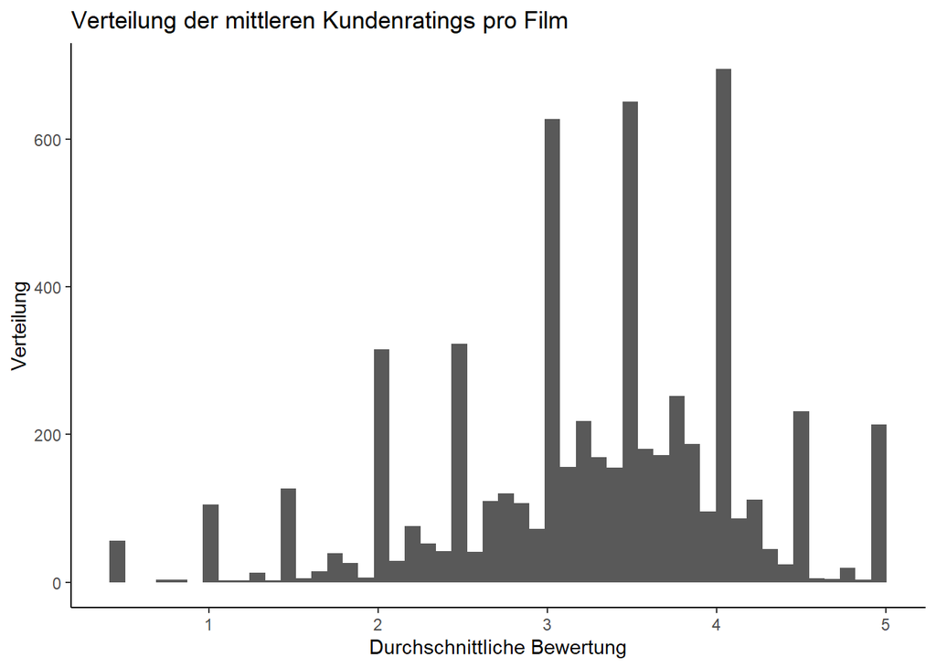

```r
mean_rating_movie1 <- ratings1 %>%
  group_by(movieId) %>%
  summarise(mean_rating = mean(rating), count = n())

ggplot(mean_rating_movie1, aes(mean_rating)) +
  geom_histogram(bins = 50) +
  labs(
    title = "Verteilung der mittleren Kundenratings pro Film",
    x = "Durchschnittliche Bewertung",
    y = "Verteilung"
  ) +
  theme_classic()
```

### 2.5.2 Alle Daten Sample 2

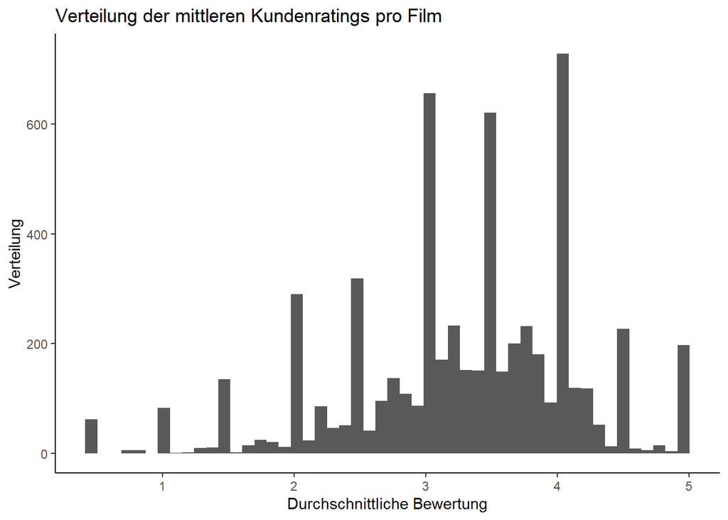

```r
mean_rating_movie2 <- ratings2 %>%
  group_by(movieId) %>%
  summarise(mean_rating = mean(rating), count = n())

ggplot(mean_rating_movie2, aes(mean_rating)) +
  geom_histogram(bins = 50) +
  labs(
    title = "Verteilung der mittleren Kundenratings pro Film",
    x = "Durchschnittliche Bewertung",
    y = "Verteilung"
  ) +
  theme_classic()
```

**Beschreibung 1:** Hier wird die Verteilung der Durchschnittswerte der Bewertungen nach Film visualisiert.

**Schlussfolgerung 1:** Da einige Filme nur wenige Bewertungen haben, liegen sehr viele Mittelwerte bei ganzen oder halben Zahlen. Deswegen gibt es bei unseren Plots einige hohe Balken.

### 2.5.3 Filme mit mehr als 5 Bewertungen Sample 1

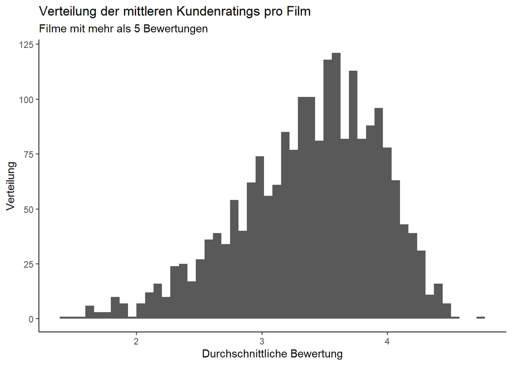

```r
ggplot(mean_rating_movie1 %>% filter(count >= 5), aes(mean_rating)) +
  geom_histogram(bins = 50) +
  labs(
    title = "Verteilung der mittleren Kundenratings pro Film",
    subtitle = "Filme mit mehr als 5 Bewertungen",
    x = "Durchschnittliche Bewertung",
    y = "Verteilung"
  ) +
  theme_classic()
```

### 2.5.4 Filme mit mehr als 5 Bewertungen Sample 2

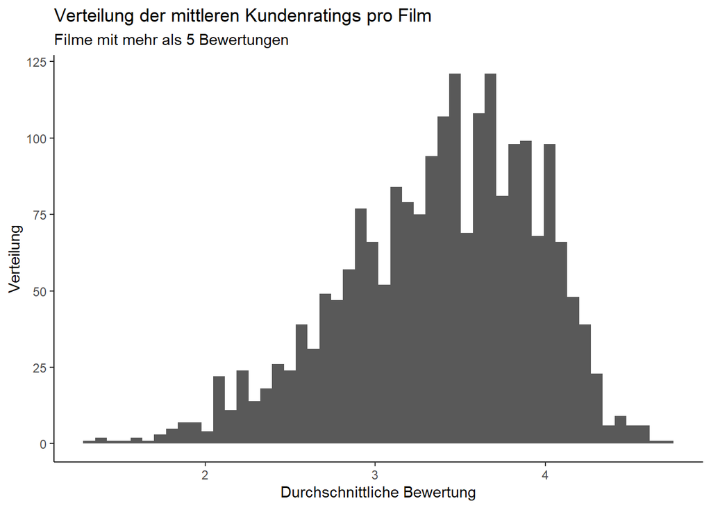

```r
ggplot(mean_rating_movie2 %>% filter(count >= 5), aes(mean_rating)) +
  geom_histogram(bins = 50) +
  labs(
    title = "Verteilung der mittleren Kundenratings pro Film",
    subtitle = "Filme mit mehr als 5 Bewertungen",
    x = "Durchschnittliche Bewertung",
    y = "Verteilung"
  ) +
  theme_classic()
```

**Beschreibung 2:** Hier wird das gleiche wie beim letzten Plot visualisiert. Jedoch wurden Filme mit weniger als 5 Bewertungen entfernt.

**Schlussfolgerung 2:** Wenn man alle Filme mit weniger als 5 Bewertungen entfernt, erkennt man, dass die Bewertungen der Filme linksschief verteilt sind.

## 2.6 Wie viele Filme, wurden je nach durchschnittlichem Kundenrating geratet.

### 2.6.1 Sample 1

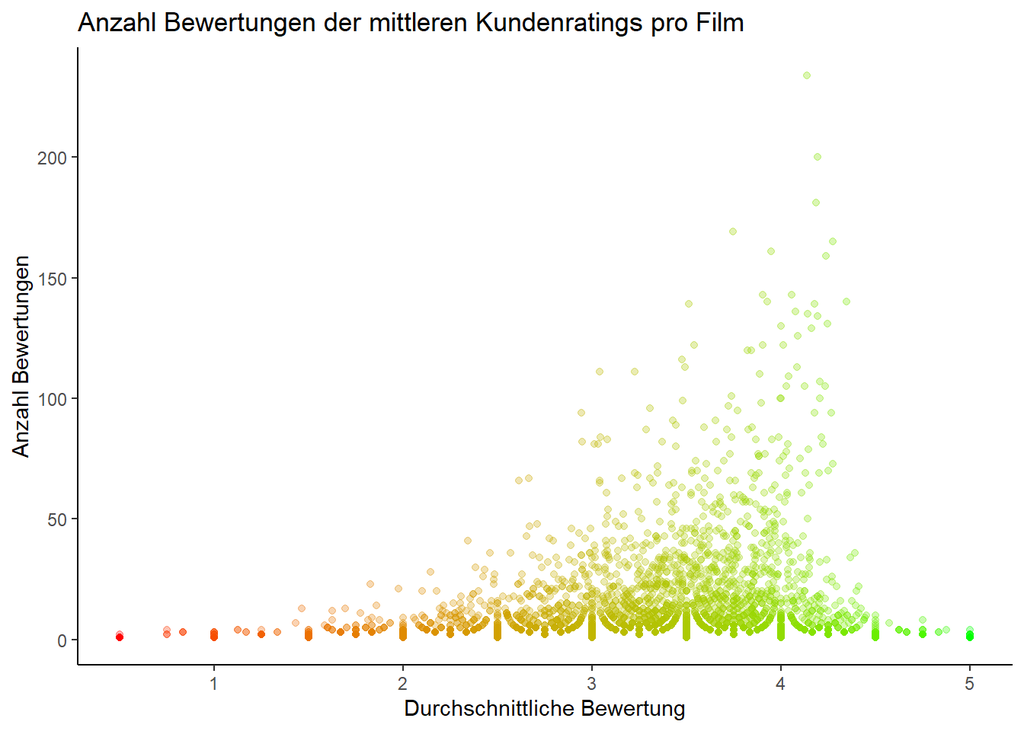

```r
ggplot(mean_rating_movie1, aes(mean_rating, count, color = mean_rating)) +
  geom_point(alpha = 0.3) +
  labs(
    title = "Anzahl Bewertungen der mittleren Kundenratings pro Film",
    x = "Durchschnittliche Bewertung",
    y = "Anzahl Bewertungen"
  ) +
  theme_classic() +
  scale_color_gradient(low = "red", high = "green") +
  theme(legend.position = "none")
```

### 2.6.2 Sample 2

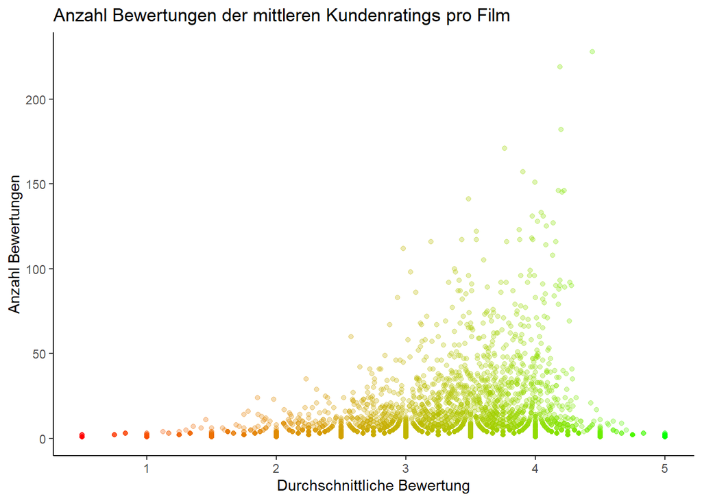

```r
ggplot(mean_rating_movie2, aes(mean_rating, count, color = mean_rating)) +
  geom_point(alpha = 0.3) +
  labs(
    title = "Anzahl Bewertungen der mittleren Kundenratings pro Film",
    x = "Durchschnittliche Bewertung",
    y = "Anzahl Bewertungen"
  ) +
  theme_classic() +
  scale_color_gradient(low = "red", high = "green") +
  theme(legend.position = "none")
```

**Beschreibung 3:** Hier werden die Durchschnittswerte der Bewertungen nach Film in Abhängigkeit von der Anzahl Bewertungen nach Film visualisiert.

**Schlussfolgerung 3:** Hier werden die gleichen Daten anders dargestellt. Man erkennt, dass desto öfters ein Film bewertet wird, desto näher liegt die durchschnittliche Bewertung bei 4. Man kann dies vielleicht begründen, indem man sagt, dass ein schlechter Film weniger geschaut und deswegen weniger bewertet wird. Jedoch können wir uns nur schwer erklären, wieso Filme mit einer Bewertung über 4 nicht so oft geschaut/bewertet werden.

## 2.7 Wie stark streuen die Ratings von individuellen Kunden?

### 2.7.1 Sample 1

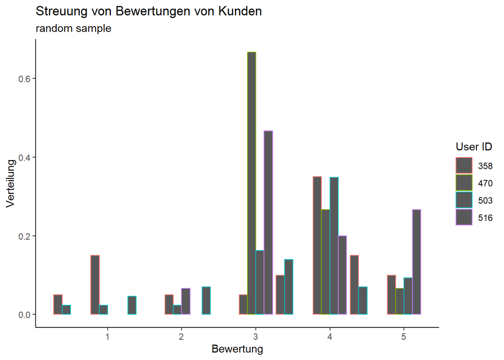

```r
set.seed(100)
sample_values <- sample(1:610, 4, replace = FALSE)

ratings1 %>%
    filter(userId %in% sample_values)%>%
  group_by(userId,rating) %>%
  summarise(number = n()) %>%
  group_by(userId)%>%
  mutate(perc = number/sum(number))%>%
  ungroup()%>%
  ggplot(., aes(rating,perc,color = factor(userId))) +
  geom_bar(stat="identity",position  = position_dodge(preserve = "single")) +
  labs(
    title = "Streuung von Bewertungen von Kunden",
    subtitle = "random sample",
    x = "Bewertung",
    y = "Verteilung",
    color = "User ID"
  ) +
  theme_classic()
```

### 2.7.2 Sample 2

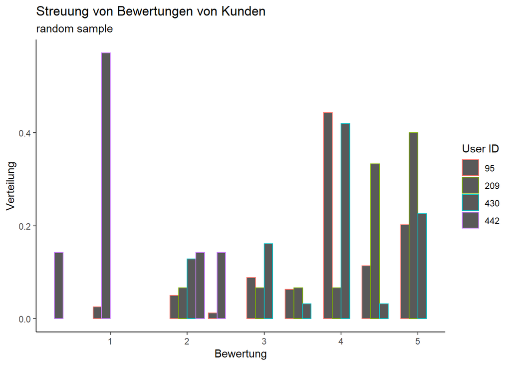

```r
set.seed(101)
sample_values <- sample(1:610, 4, replace = FALSE)

ratings2 %>%
  filter(userId %in% sample_values)%>%
  group_by(userId,rating) %>%
  summarise(number = n()) %>%
  group_by(userId)%>%
  mutate(perc = number/sum(number))%>%
  ungroup()%>%
  ggplot(., aes(rating,perc,color = factor(userId))) +
  geom_bar(stat="identity",position  = position_dodge(preserve = "single")) +
  labs(
    title = "Streuung von Bewertungen von Kunden",
    subtitle = "random sample",
    x = "Bewertung",
    y = "Verteilung",
    color = "User ID"
  ) +
  theme_classic()
```

**Beschreibung:** Die meisten Kunden haben tendenziell hohe Bewertungen. Es gibt Kunden die keine tiefe Bewertungen abgeben. Solche Kunden die tiefe Bewertungen abgeben (z.B. User ID 442), varieren bei ihren tiefen Bewertungen. Auch bei den anderen Bewertungen, varieren die Kunden stark.

**Interpretation:** Es gibt diverse Kunden, die nur Filme schauen, welche sie auch mögen.

## 2.8 Wie stark streuen die Ratings von allen Kunden

### 2.8.1 Sample 1

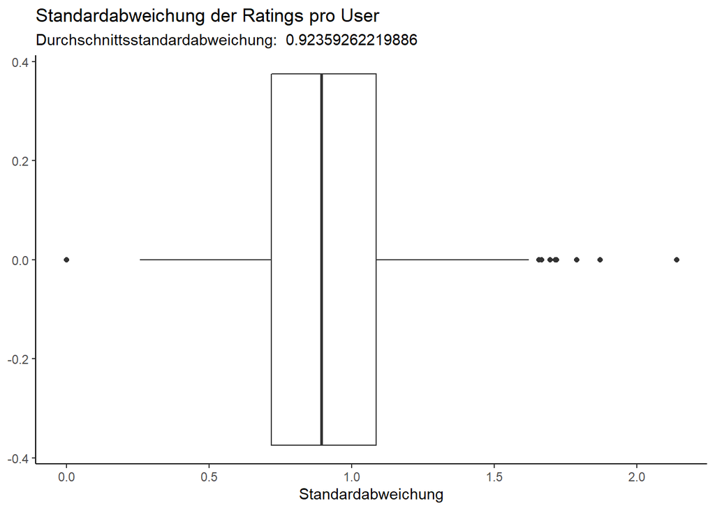

```r
sd_ratings1 <- ratings1 %>%
  group_by(userId) %>%
  summarise(SD = sd(rating), count = n())


ggplot(sd_ratings1, aes(SD)) +
  geom_boxplot() +
  labs(
    title = "Standardabweichung der Ratings pro User",
    x = "Standardabweichung",
    subtitle = paste("Durchschnittsstandardabweichung: ", mean(sd_ratings1$SD)),
  ) +
  theme_classic()
```

### 2.8.2 Sample 2.2

[figure not shown]

```r
sd_ratings2 <- ratings2 %>%
  group_by(userId) %>%
  summarise(SD = sd(rating), count = n())

ggplot(sd_ratings2, aes(SD)) +
  geom_boxplot() +
  labs(
    title = "Standardabweichung der Ratings pro User",
    x = "Standardabweichung",
    subtitle = paste("Durchschnittsstandardabweichung: ", mean(sd_ratings1$SD)),
  ) +
  theme_classic()
```

**Beschreibung:** Die Standardabweichungen der Bewertungen der User werden visualisiert. Dabei erkennt man, dass es eine Observation bei 0 gibt. Die meisten Observationen liegen zwischen 0.7 und 1.2

**Schlussfolgerung:** Nur ein User hat alles gleiche Bewertungen. Wenn dieser User für einen Recommender mit standartisierten Daten verwendet wird ist es nicht mehr möglich eine Vorhersage zu machen.

Ansonsten ist der Median der Standartabweichungen leicht unter 1. Dies macht bei leicht linksschiefen Daten Sinn.

## 2.9 Welchen Einfluss hat die Normierung der Ratings pro Kunde auf deren Verteilung?

### 2.9.1 Sample 1

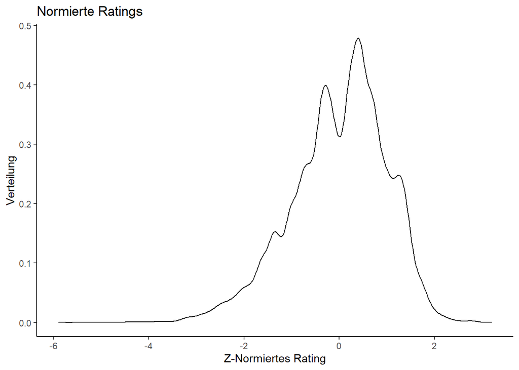

```r
norm_ratings1 <- ratings1 %>%
  group_by(userId) %>%
  summarise(mean_rating = mean(rating), sd_rating = sd(rating)) %>%
  full_join(., ratings1, by = "userId")

norm_ratings1$z_rating <- (norm_ratings1$rating - norm_ratings1$mean_rating) /
  norm_ratings1$sd_rating

ggplot(norm_ratings1, aes(z_rating)) +
  geom_density() +
  labs(
    title = "Normierte Ratings",
    x = "Z-Normiertes Rating",
    y = "Verteilung"
  ) +
  theme_classic()
```

### 2.9.2 Sample 2

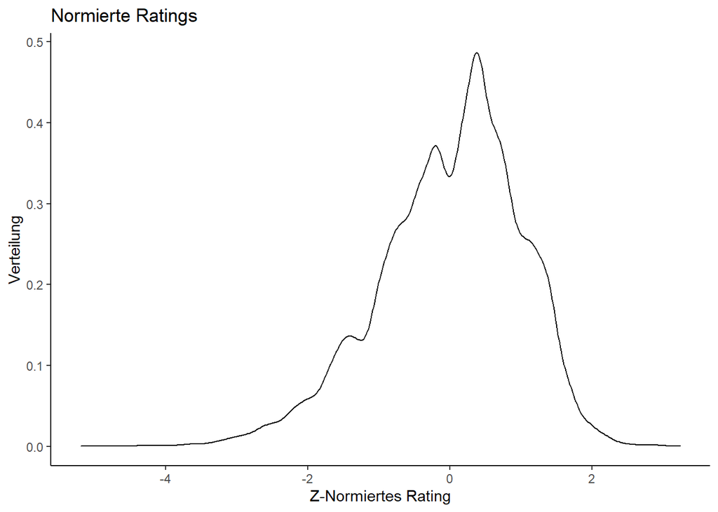

```r
norm_ratings2 <- ratings2 %>%
  group_by(userId) %>%
  summarise(mean_rating = mean(rating), sd_rating = sd(rating)) %>%
  full_join(., ratings2, by = "userId")

norm_ratings2$z_rating <- (norm_ratings2$rating - norm_ratings2$mean_rating) /
  norm_ratings2$sd_rating

ggplot(norm_ratings2, aes(z_rating)) +
  geom_density() +
  labs(
    title = "Normierte Ratings",
    x = "Z-Normiertes Rating",
    y = "Verteilung"
  ) +
  theme_classic()
```

**Schlussfolgerung:** Alle Ratings unter 0 könnte man als “gefällt dem User nicht” interpretieren und alle Rating über 0 könnte man als “gefällt dem User” interpretieren. Desto weiter sich die Bewertung von 0 entfernt desto mehr oder weniger gefällt dem User der Film.

## 2.10 Welche strukturellen Charakteristika (z.B.Sparsity) und Auffälligkeiten zeigt die User-Item Matrix?

### 2.10.1 Sample 1

```r
user_item1 <- norm_ratings1 %>%
  select(movieId, userId, z_rating) %>%
  pivot_wider(names_from = movieId, values_from = z_rating)

sparsity1 <- round(sum(is.na(user_item1)) / (dim(user_item1)[1] * (dim(user_item1)[2])),2)
```

### 2.10.2 Sample 2

```r
user_item2 <- norm_ratings2 %>%
  select(movieId, userId, z_rating) %>%
  pivot_wider(names_from = movieId, values_from = z_rating)

sparsity2 <- round(sum(is.na(user_item2)) / (dim(user_item2)[1] * (dim(user_item2)[2])),2)
```

**Schlussfolgerung:** Beide User-Item Matrizen sind etwa zu 98.6 % Sparse. Dies bedeutet, dass ein grosser Teil der Daten mit NA’s besetzt ist. Für spätere Berechnungen ist es entscheidend, was mit diesen NA’s gemacht wird.

# 3 Datenreduktion

Die Daten wurden auf 400 Kunden und 700 Filme reduziert, indem Filme und Kunden mit sehr wenigen Ratings entfernt wurden.

## 3.1 Reduktion

### 3.1.1 Sample 1

```r
# Filter 700 most rated movies
top_n_movies1 <- norm_ratings1 %>%
  group_by(movieId) %>%
  count() %>%
  arrange(desc(n)) %>%
  head(700)

# Join data on 700 most rated movies
user_item_r1 <-
  left_join(
    top_n_movies1,
    norm_ratings1,
    by = "movieId"
  )

# Filter 700 most rated user
top_n_user1 <- user_item_r1 %>%
  group_by(userId) %>%
  count() %>%
  arrange(desc(n)) %>%
  head(400) %>%
  ungroup()

# Join data on 400 most rated user (only 700 movies)
user_item_r1 <-
  left_join(
    top_n_user1,
    user_item_r1,
    by = "userId"
  ) %>%
  select(userId, movieId, z_rating)

# Pivot wider
m_user_item_r1 <- user_item_r1 %>%
  pivot_wider(names_from = movieId, values_from = z_rating) %>%
  column_to_rownames(., var = "userId")
```

### 3.1.2 Sample 2

```r
# Filter 700 most rated movies
top_n_movies2 <- norm_ratings2 %>%
  group_by(movieId) %>%
  count() %>%
  arrange(desc(n)) %>%
  head(700)

# Join data on 700 most rated movies
user_item_r2 <-
  left_join(
    top_n_movies2,
    norm_ratings2,
    by = "movieId"
  )

# Filter 700 most rated user
top_n_user2 <- user_item_r2 %>%
  group_by(userId) %>%
  count() %>%
  arrange(desc(n)) %>%
  head(400) %>%
  ungroup()

# Join data on 400 most rated user (only 700 movies)
user_item_r2 <-
  left_join(
    top_n_user2,
    user_item_r2,
    by = "userId"
  ) %>%
  select(userId, movieId, z_rating)

# Pivot wider
m_user_item_r2 <- user_item_r2 %>%
  pivot_wider(names_from = movieId, values_from = z_rating) %>%
  column_to_rownames(., var = "userId")
```

## 3.2 Sparsity nach Datenreduktion

### 3.2.1 Sample 1

```r
# Sparsity Sample 1
sparsity_after_red1 <- sum(is.na(m_user_item_r1)) / (dim(m_user_item_r1)[1] * (dim(m_user_item_r1)[2]))
```

### 3.2.2 Sample 2

```r
# Sparsity Sample 2
sparsity_after_red2 <- sum(is.na(m_user_item_r2)) / (dim(m_user_item_r2)[1] * (dim(m_user_item_r2)[2]))
```

**Schlussfolgerung:** Somit wurden die Sparsities zum kompletten Datensatz deutlich reduziert. Das bedeutet, dass die User-Item Matrix im Verhältniss mehr Ratings beinhalten.

## 3.3 Mittlere Kundenratings pro Film vor und nach Datenreduktion

### 3.3.1 Sample 1

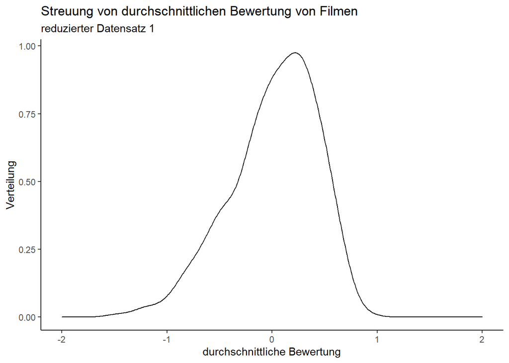

```r
moviemeans_reducted1 <- colMeans(m_user_item_r1, na.rm = TRUE)
moviemeans_reducted1 <- data.frame(moviemeans_reducted1)
ggplot(moviemeans_reducted1, aes(moviemeans_reducted1)) +
  geom_density() +
  labs(
    title = "Streuung von durchschnittlichen Bewertung von Filmen",
    subtitle = "reduzierter Datensatz 1",
    x = "durchschnittliche Bewertung",
    y = "Verteilung"
  ) +
  theme_classic() +
  xlim(-2, 2)
```

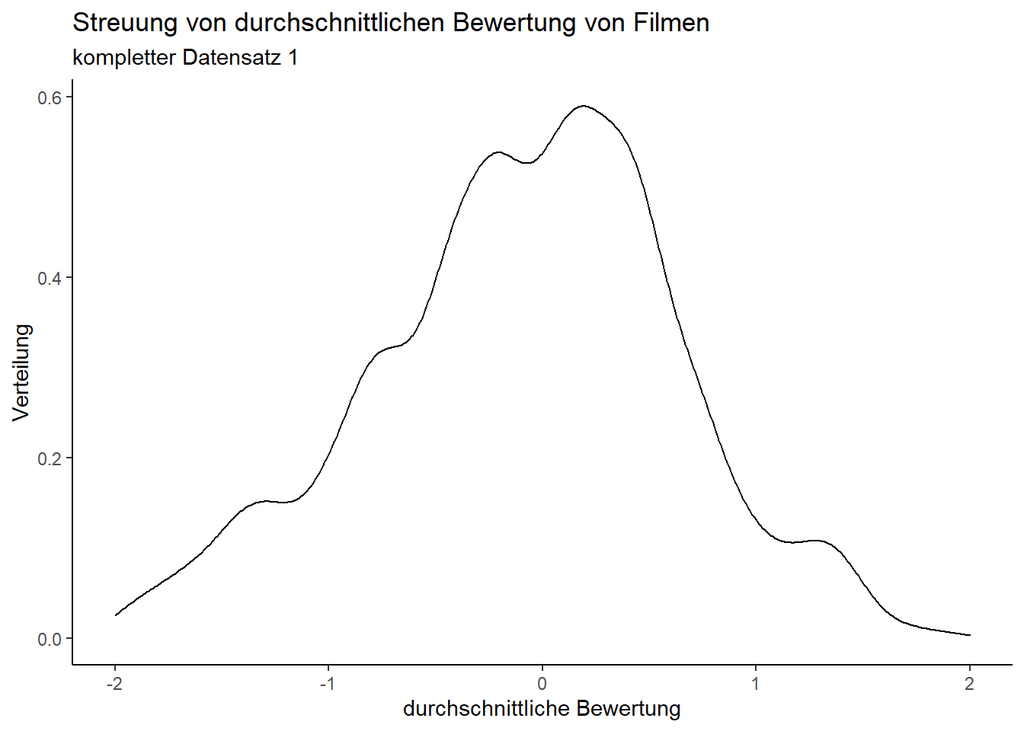

```r
moviemeans1 <- colMeans(user_item1 %>% column_to_rownames(., var = "userId"), na.rm = TRUE)
moviemeans1 <- data.frame(moviemeans1)
ggplot(moviemeans1, aes(moviemeans1)) +
  geom_density() +
  labs(
    title = "Streuung von durchschnittlichen Bewertung von Filmen",
    subtitle = "kompletter Datensatz 1",
    x = "durchschnittliche Bewertung",
    y = "Verteilung"
  ) +
  theme_classic() +
  xlim(-2, 2)
```

### 3.3.2 Sample 2

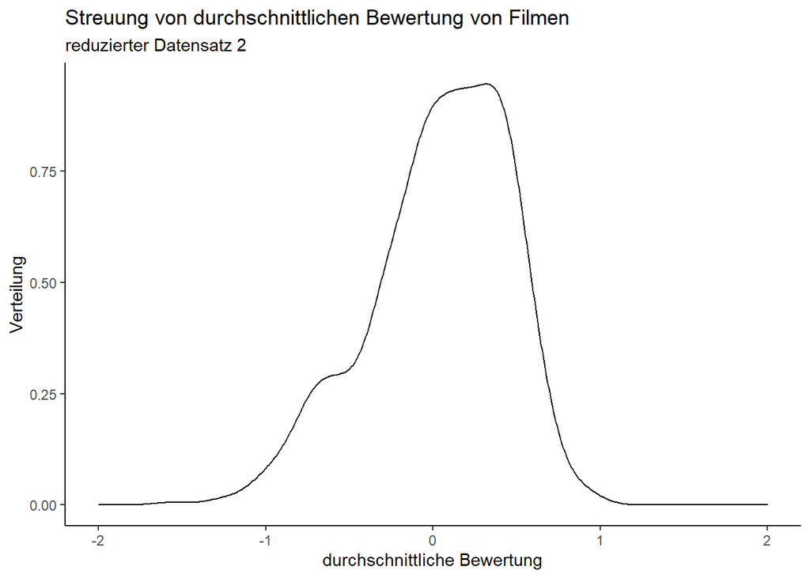

```r
moviemeans_reducted2 <- colMeans(m_user_item_r2, na.rm = TRUE)
moviemeans_reducted2 <- data.frame(moviemeans_reducted2)
ggplot(moviemeans_reducted2, aes(moviemeans_reducted2)) +
  geom_density() +
  labs(
    title = "Streuung von durchschnittlichen Bewertung von Filmen",
    subtitle = "reduzierter Datensatz 2",
    x = "durchschnittliche Bewertung",
    y = "Verteilung"
  ) +
  theme_classic() +
  xlim(-2, 2)
```

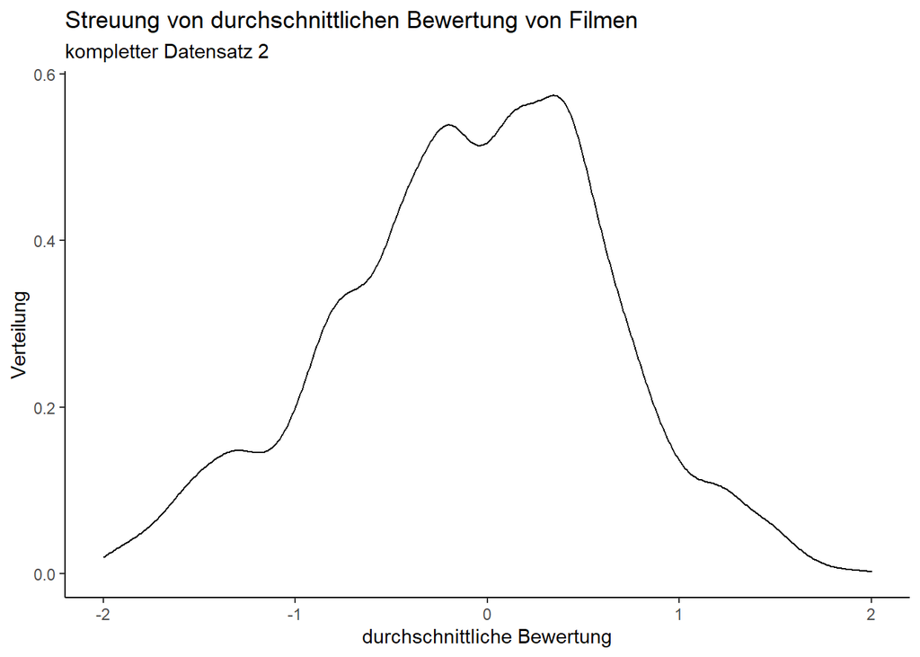

```r
moviemeans2 <- colMeans(user_item2 %>% column_to_rownames(., var = "userId"), na.rm = TRUE)
moviemeans2 <- data.frame(moviemeans2)
ggplot(moviemeans2, aes(moviemeans2)) +
  geom_density() +
  labs(
    title = "Streuung von durchschnittlichen Bewertung von Filmen",
    subtitle = "kompletter Datensatz 2",
    x = "durchschnittliche Bewertung",
    y = "Verteilung"
  ) +
  theme_classic() +
  xlim(-2, 2)
```

**Beschreibung:** Hier wird die Streuung der durchschnittlichen Bewertung einzelner Filme visualisiert. Es wird dabei der reduzierte Datensatz mit dem kompletten Datensatz verglichen.

**Schlussfolgerung:** Man erkennt, dass die Daten beim reduzierten Datensatz grösstenteils nur im Bereich [-1, 1] streuen. Dies ist auch realistisch da es wahrscheinlicher ist, dass ein Film welches nur 1 Mal bewertet wurde eine Bewertung von z.B. -2 hat, als dass 10 User den gleichen Film so schlecht bewerten, dass der Durchschnitt bei -2 liegt.

## 3.4 Quantifiziere “Intersection over Union” der Ratings der unterschiedlich reduzierten Datensätze.

```r
intersection <- nrow(inner_join(user_item_r1, user_item_r2, by = c("movieId", "userId")))
union <- nrow(user_item_r1) +  nrow(user_item_r2) - intersection
intersection_over_union <- round(intersection / union,2)
```

**Beschreibung:** Die “Intersection over Union” ist 0.29 gross. Die berechnete Zahl bezeichnet das Verhältnis von Bewertungen, welche in beiden Datensätzen vorhanden ist.

# 4 Analyse Ähnlichkeitsmatrix

## 4.1 Zerlege den reduzierten MovieLense Datensatz in ein disjunktes Trainings- und Testdatenset im Verhältnis 4:1

### 4.1.1 Sample 1

```r
set.seed(69)
split1 <- initial_split(m_user_item_r1, prop = 0.80)
training1 <- as.matrix(training(split1))
test1 <- as.matrix(testing(split1))
```

### 4.1.2 Sample 2

```r
set.seed(100)
split2 <- initial_split(m_user_item_r2, prop = 0.80)
training2 <- as.matrix(training(split2))
test2 <- as.matrix(testing(split2))
```

## 4.2 Trainiere ein IBCF Modell mit 30 Nachbarn und Cosine Similarity

### 4.2.1 Sample 1

```r
IBCF1 <- Recommender(as(training1, "realRatingMatrix"), "IBCF",
  param = list(normalize = NULL, method = "cosine", k = 30, na_as_zero = TRUE)
)
```

### 4.2.2 Sample 2

```r
IBCF2 <- Recommender(as(training2, "realRatingMatrix"), "IBCF",
  param = list(normalize = NULL, method = "cosine", k = 30,na_as_zero = TRUE)
)
```

## 4.3 Bestimme die Verteilung der Filme, welche bei IBCF für paarweise Ähnlichkeitsvergleiche verwendet werden

### 4.3.1 Sample 1

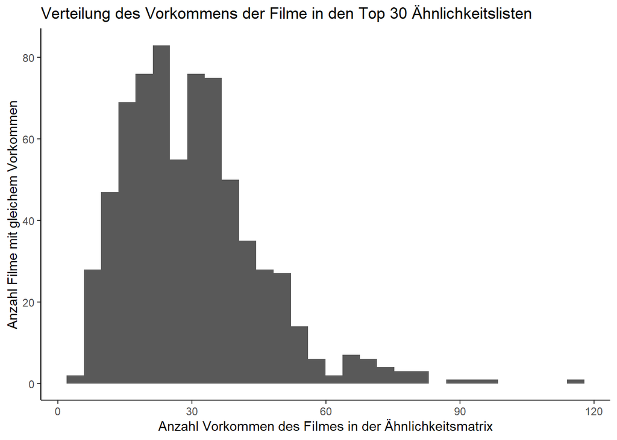

```r
# extract IBCF similarity matrix
IBCF_sim_matrix1 <- as.data.frame(as.matrix(IBCF1@model[["sim"]]))

# count number of occurrences
IBCF_freq1 <- as.data.frame(colSums(IBCF_sim_matrix1 != 0), optional = TRUE)
colnames(IBCF_freq1) <- "frequency"
ggplot(IBCF_freq1, aes(frequency)) +
  geom_histogram(bins = 30) +
  labs(
    title = "Verteilung des Vorkommens der Filme in den Top 30 Ähnlichkeitslisten",
    x = "Anzahl Vorkommen des Filmes in der Ähnlichkeitsmatrix",
    y = "Anzahl Filme mit gleichem Vorkommen"
  ) +
  theme_classic()
```

### 4.3.2 Sample 2

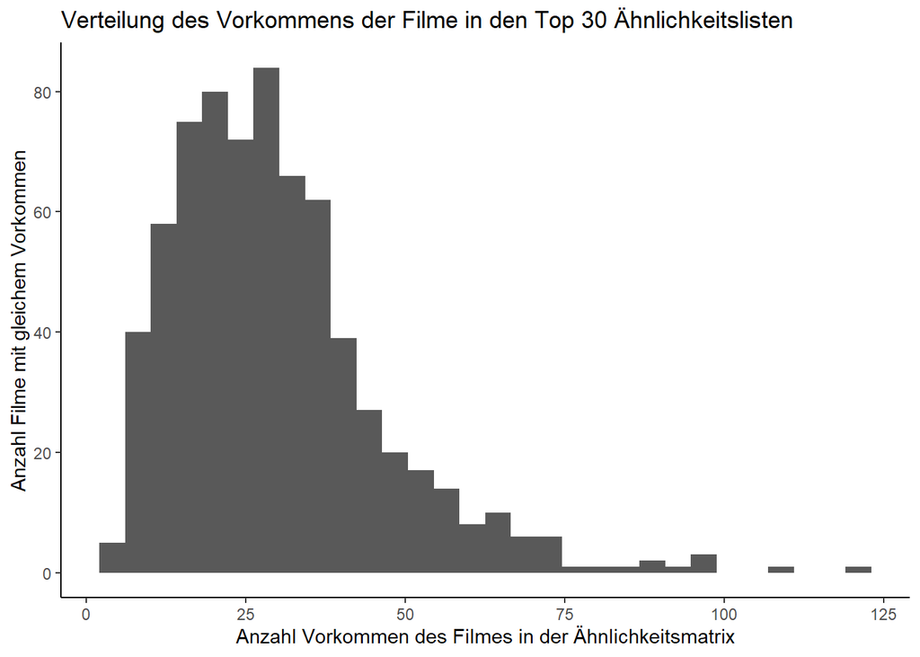

```r
# extract IBCF similarity matrix
IBCF_sim_matrix2 <- as.data.frame(as.matrix(IBCF2@model[["sim"]]))

# count number of occurrences
IBCF_freq2 <- as.data.frame(colSums(IBCF_sim_matrix2 != 0), optional = TRUE)
colnames(IBCF_freq2) <- "frequency"
ggplot(IBCF_freq2, aes(frequency)) +
  geom_histogram(bins = 30) +
  labs(
    title = "Verteilung des Vorkommens der Filme in den Top 30 Ähnlichkeitslisten",
    x = "Anzahl Vorkommen des Filmes in der Ähnlichkeitsmatrix",
    y = "Anzahl Filme mit gleichem Vorkommen"
  ) +
  theme_classic()
```

**Beschreibung:** Hier wird visualisiert, wie viele Filme wie oft in der Top 30 Ähnlichkeitsliste jedes einzelnes Filmes auftreten. Die y-Achse beschreibt, wieviel Filme in X Top 30 Ähnlichkeitslisten vorkommt und die x-Achse beschreibt, in wievielen Top 30 Ähnlichkeitsliste ein bestimmter Film vorkommt.

## 4.4 Bestimme die Filme, die am häufigsten in der Cosine-Ähnlichkeitsmatrix auftauchen und analysiere deren Vorkommen und Ratings im reduzierten Datensatz.

### 4.4.1 Häufigkeit der Filme

#### 4.4.1.1 Sample 1

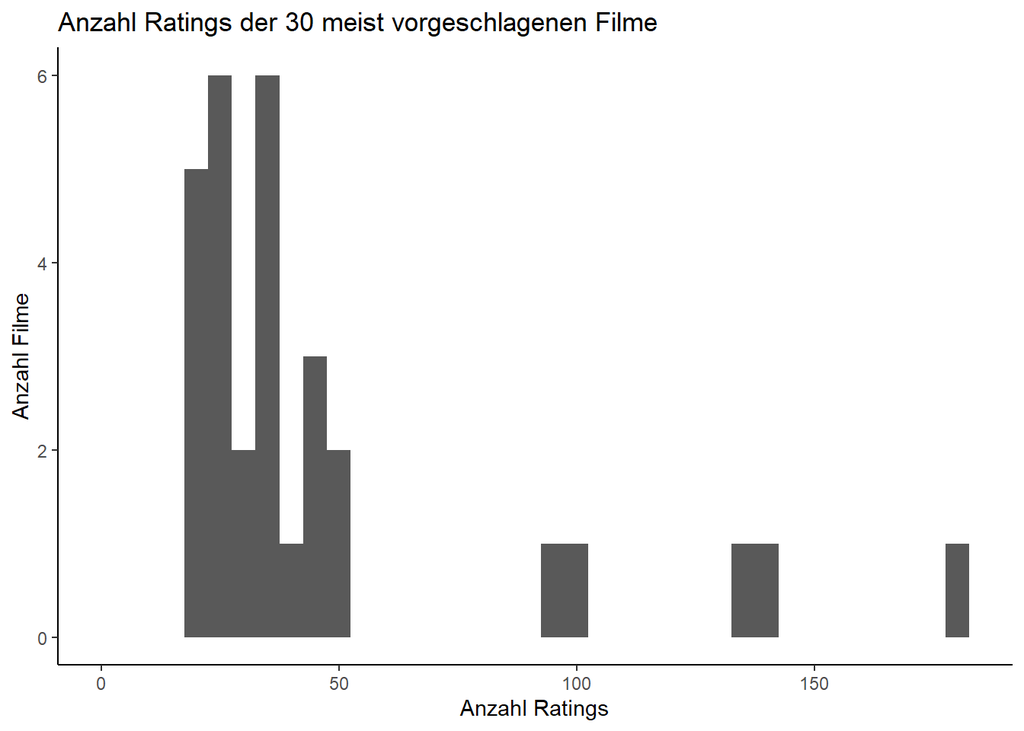

```r
# Add movieId as column
IBCF_freq1$movieId <- rownames(IBCF_freq1)

# sort by frequency, select most frequent movies
IBCF_freq_head1 <- IBCF_freq1 %>%
  arrange(desc(frequency)) %>%
  head(30) %>%
  convert(int(movieId))

# count occurrency and the mean rating of the reduced data
IBCF_freq_head1 <- left_join(IBCF_freq_head1, norm_ratings1, by = "movieId") %>%
  group_by(movieId) %>%
  summarise(
    count = n(),
    mean = mean(z_rating)
  )

ggplot(IBCF_freq_head1, aes(count)) +
  geom_histogram(binwidth = 5) +
  labs(
    title = "Anzahl Ratings der 30 meist vorgeschlagenen Filme",
    x = "Anzahl Ratings",
    y = "Anzahl Filme"
  ) +
  xlim(0, NA) +
  theme_classic()
```

#### 4.4.1.2 Sample 2

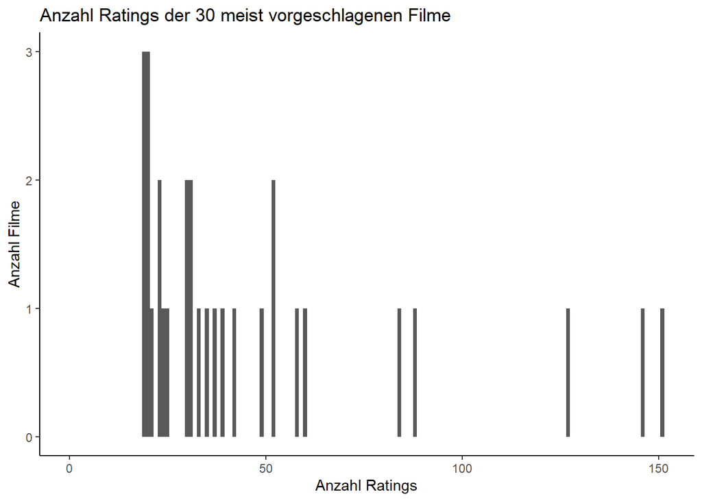

```r
# Add movieId as column
IBCF_freq2$movieId <- rownames(IBCF_freq2)

# sort by frequency, select most frequent movies
IBCF_freq_head2 <- IBCF_freq2 %>%
  arrange(desc(frequency)) %>%
  head(30) %>%
  convert(int(movieId))

# count occurrency and the mean rating of the reduced data
IBCF_freq_head2 <- left_join(IBCF_freq_head2, norm_ratings2, by = "movieId") %>%
  group_by(movieId) %>%
  summarise(
    count = n(),
    mean = mean(z_rating)
  )

ggplot(IBCF_freq_head2, aes(count)) +
  geom_histogram(binwidth = 1) +
  labs(
    title = "Anzahl Ratings der 30 meist vorgeschlagenen Filme",
    x = "Anzahl Ratings",
    y = "Anzahl Filme"
  ) +
  xlim(0, NA) +
  theme_classic()
```

**Beschreibung:** Aus den Top 30 ähnlichen Filmen aller Filme, werden die Top 30 Filme mit den meisten Vorkommen ausgewählt und danach die Anzahl Ratings dieser Filme visualisiert.

**Schlussfolgerung:** Die am meist vorgeschlagenen Filme haben in beiden reduzierten Datensätze um die 20 oder mehr Ratings. Beim ersten Datensatz haben die meisten Filme meistens zwischen 20 und 50 Ratings. Beim zweiten Datensatz haben die meisten Filme meistens um die 20 bis 30 Ratings.

### 4.4.2 Durchschnittliche Ratings der Filme

#### 4.4.2.1 Sample 1

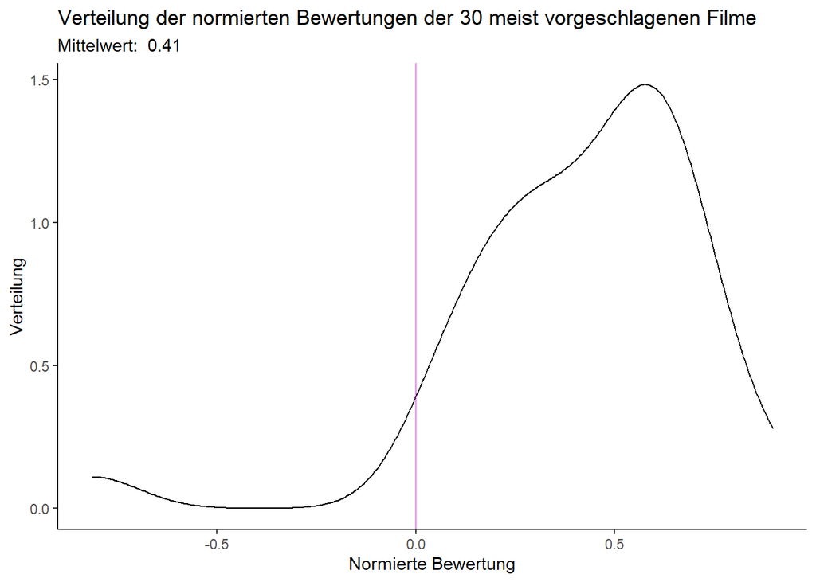

```r
ggplot(IBCF_freq_head1, aes(mean)) +
  geom_density() +
  geom_vline(xintercept = 0, alpha = 0.5, color = "magenta") +
  labs(
    title = "Verteilung der normierten Bewertungen der 30 meist vorgeschlagenen Filme",
    subtitle = paste("Mittelwert: ", round(mean(IBCF_freq_head1$mean),2)),
    x = "Normierte Bewertung",
    y = "Verteilung"
  ) +
  theme_classic()
```

#### 4.4.2.2 Sample 2

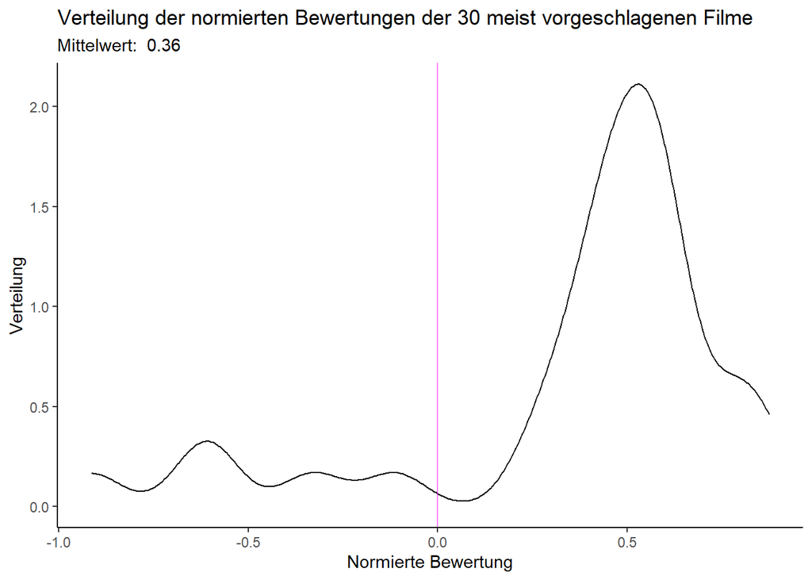

```r
ggplot(IBCF_freq_head2, aes(mean)) +
  geom_density() +
  geom_vline(xintercept = 0, alpha = 0.5, color = "magenta") +
  labs(
    title = "Verteilung der normierten Bewertungen der 30 meist vorgeschlagenen Filme",
    subtitle = paste("Mittelwert: ", round(mean(IBCF_freq_head2$mean),2)),
    x = "Normierte Bewertung",
    y = "Verteilung"
  ) +
  theme_classic()
```

**Beschreibung:** Hier wird die Verteilung der normierten Bewertungen der 30 meist vorgeschlagenen Filme visualisiert. Weiterhin haben wir eine vertikale Linie implementiert, welche die Boundary zwischen einer guten (rechts) und einer schlechten (links) Bewertung bildet.

**Schlussfolgerung:** Die 30 am meist vorgeschlagenen Filme tendieren dazu, überdurchschnittlich gut bewertete Filme zu sein. Das können wir daraus formulieren, das der Mittelwert der Bewertungen beider Datensätze über den Wert 0 liegen. Beim ersten Datensatz ist dies klarer zu erkennen, als beim zweiten.

# 5 Implementierung Ähnlichkeitsmatrix

## 5.1 Implementierung

### 5.1.1 Berechnung der cosinus/jaccard similarity

```r
calculate_jaccard <- function(arr1, arr2) {
  # Check which columns are available
  vals <- (!is.na(array(arr1)) & !is.na(array(arr2)))
  # Remove movieId column from jaccard similarity
  vals[1] <- FALSE
  # If there are common not na values, calculate jac sim
  if (sum(vals) != 0) {
    both_true <- arr1[vals] & arr2[vals]
    either_true <- arr1[vals] | arr2[vals]
    jac_sim <- sum(both_true) / sum(either_true)
    return(jac_sim)
  }
  # If not, return NA
  return(NA)
}

calculate_cos <- function(arr1, arr2) {
  # Check which columns are available
  vals <- (!is.na(array(arr1)) & !is.na(array(arr2)))
  # Remove movieId column from cos similarity
  vals[1] <- FALSE
  # If there are common not na values, calculate cos sim
  if (sum(vals) != 0) {
    arr1 <- arr1[vals]
    arr2 <- arr2[vals]
    ab <- as.matrix(arr1) %*% t(arr2)
    norma <- norm(arr1, type = "2")
    normb <- norm(arr2, type = "2")
    cos_sim <- ((ab / (norma * normb)) + 1) / 2
    return(cos_sim)
  }
  # If not, return NA
  return(NA)
}
```

### 5.1.2 Berechnung der Ähnlichkeitsmatrix

```r
getCorrelationMatrix <- function(data, cos = TRUE) {
  # Get array with movieId's
  movies <- as.character(data$movieId)

  # Create correlation matrix and set diag to 1
  correlations <- matrix(
    NA,
    nrow = length(movies),
    ncol = length(movies),
    dimnames = list(movies, movies)
  )
  diag(correlations) <- 1

  # Iterate through every movie and preload column
  i_counter <- 0
  for (i in movies) {
    i_counter <- i_counter + 1
    row_i <- data %>% filter(movieId == i)
    # For every movie, iterate through every movie
    j_counter <- 0
    for (j in movies) {
      j_counter <- j_counter + 1
      # If cos similarity was already calculated, skip, else continue
      if (i_counter <= j_counter) {
        # calculate similarity
        row_j <- data %>% filter(movieId == j)
        if (cos) {
          sim <- calculate_cos(row_i, row_j)
        } else {
          sim <- calculate_jaccard(row_i, row_j)
        }
        # set sim in sim matrix
        correlations[i, j] <- sim
        correlations[j, i] <- sim
      }
    }
    # Track progress
    # print(paste(i_counter, " Datasets done"))
  }
  # Return correlation matrix
  return(correlations)
}

numToBool <- function(x) (x >= 0)
```

### 5.1.3 Effiziente Berechnung der Ähnlichkeitsmatrix (cos sim), wenn man NA’s mit 0 ersetzt

```r
getCorrelationMatrixCosNoNA <- function(data, cos = TRUE) {
  data[is.na(data)] <- 0
  data <- t(data)
  AAT <- data %*% t(data)
  norm_ <- rep(NA, nrow(data))
  for (i in 1:nrow(data)) {
    norm_[i] <- sqrt(sum(data[i, ]^2))
  }
  norms <- norm_ %*% t(norm_)
  result <- AAT / norms
  return((result + 1) / 2)
}
```

## 5.2 Berechnung der Ähnlichkeitsmatrizen

### 5.2.1 Sample 1

```r
# Erstellung der User-Rating Matrix
set.seed(100)
sample_values1 <- sample(1:6819, 300, replace = FALSE)

norm_ratings1 <- ratings1 %>%
  group_by(userId) %>%
  summarise(mean_rating = mean(rating), sd_rating = sd(rating)) %>%
  full_join(., ratings1, by = "userId")

norm_ratings1$z_rating <- (norm_ratings1$rating - norm_ratings1$mean_rating) /
  norm_ratings1$sd_rating

item_user_random_100_1 <- norm_ratings1 %>%
  select(movieId, userId, z_rating) %>%
  pivot_wider(names_from = userId, values_from = z_rating) %>%
  filter(movieId %in% sample_values1) %>%
  head(100)

item_user_random_100_bool1 <- item_user_random_100_1 %>% mutate(across(!matches("movieId"), numToBool))
```

```r
corrNumb1 <- getCorrelationMatrix(item_user_random_100_1, cos = TRUE)
corrBool1 <- getCorrelationMatrix(item_user_random_100_bool1, cos = FALSE)
```

### 5.2.2 Sample 2

```r
# Erstellung der User-Rating Matrix
set.seed(100)
sample_values2 <- sample(1:6819, 300, replace = FALSE)

norm_ratings2 <- ratings2 %>%
  group_by(userId) %>%
  summarise(mean_rating = mean(rating), sd_rating = sd(rating)) %>%
  full_join(., ratings2, by = "userId")

norm_ratings2$z_rating <- (norm_ratings2$rating - norm_ratings2$mean_rating) /
  norm_ratings2$sd_rating

item_user_random_100_2 <- norm_ratings2 %>%
  select(movieId, userId, z_rating) %>%
  pivot_wider(names_from = userId, values_from = z_rating) %>%
  filter(movieId %in% sample_values1) %>%
  head(100)

item_user_random_100_bool2 <- item_user_random_100_2 %>% mutate(across(!matches("movieId"), numToBool))
```

```r
corrNumb2 <- getCorrelationMatrix(item_user_random_100_2, cos = TRUE)
corrBool2 <- getCorrelationMatrix(item_user_random_100_bool2, cos = FALSE)
```

## 5.3 Vergleich mit recommenderlabs

### 5.3.1 Sample 1

```r
item_user_random_100_recommenderlab1 <- item_user_random_100_1 %>%
  column_to_rownames(., var = "movieId") %>%
  as.matrix(.) %>%
  t(.)

corrNumbRL1 <- as.matrix(similarity(as(item_user_random_100_recommenderlab1, "realRatingMatrix"), method = "cosine", which = "items"))

corrNumbRL1[1:6, 1:6]
```

```
##           2478        3273       457       223        2366      3386
## 2478        NA 0.387965776 0.1878327 0.6764612 0.583930818 0.2678179
## 3273 0.3879658          NA 0.2105259 0.4300789 0.003323487 0.3019346
## 457  0.1878327 0.210525910        NA 0.5498116 0.506941205 0.6544472
## 223  0.6764612 0.430078886 0.5498116        NA 0.473340847 0.5391478
## 2366 0.5839308 0.003323487 0.5069412 0.4733408          NA 0.8759123
## 3386 0.2678179 0.301934611 0.6544472 0.5391478 0.875912271        NA
```

```r
corrNumb1[1:6, 1:6]
```

```
##           2478       3273       457       223       2366      3386
## 2478 1.0000000 0.38796536 0.1878325 0.6764613 0.58393080 0.2678174
## 3273 0.3879654 1.00000000 0.2105260 0.4300789 0.00332348 0.3019346
## 457  0.1878325 0.21052604 1.0000000 0.5498115 0.50694134 0.6544472
## 223  0.6764613 0.43007890 0.5498115 1.0000000 0.47334097 0.5391479
## 2366 0.5839308 0.00332348 0.5069413 0.4733410 1.00000000 0.8759123
## 3386 0.2678174 0.30193458 0.6544472 0.5391479 0.87591235 1.0000000
```

```r
item_user_random_100_bool_recommenderlab1 <- item_user_random_100_bool1 %>%
  column_to_rownames(., var = "movieId") %>%
  t(.)

corrBoolRL1 <- as.matrix(similarity(as(item_user_random_100_bool_recommenderlab1, "realRatingMatrix"), method = "jaccard", which = "items"))

corrBoolRL1[1:6, 1:6]
```

```
##           2478 3273       457       223 2366      3386
## 2478        NA 0.00 0.1428571 0.3333333 0.00 0.0000000
## 3273 0.0000000   NA 0.5000000 0.2500000 0.00 0.5000000
## 457  0.1428571 0.50        NA 0.6521739 0.40 0.5714286
## 223  0.3333333 0.25 0.6521739        NA 0.25 0.4285714
## 2366 0.0000000 0.00 0.4000000 0.2500000   NA 1.0000000
## 3386 0.0000000 0.50 0.5714286 0.4285714 1.00        NA
```

```r
corrBool1[1:6, 1:6]
```

```
##           2478 3273       457       223 2366      3386
## 2478 1.0000000 0.00 0.1428571 0.3333333 0.00 0.0000000
## 3273 0.0000000 1.00 0.5000000 0.2500000 0.00 0.5000000
## 457  0.1428571 0.50 1.0000000 0.6521739 0.40 0.5714286
## 223  0.3333333 0.25 0.6521739 1.0000000 0.25 0.4285714
## 2366 0.0000000 0.00 0.4000000 0.2500000 1.00       NaN
## 3386 0.0000000 0.50 0.5714286 0.4285714  NaN 1.0000000
```

### 5.3.2 Sample 2

```r
item_user_random_100_recommenderlab2 <- item_user_random_100_2 %>%
  column_to_rownames(., var = "movieId") %>%
  as.matrix(.) %>%
  t(.)

corrNumbRL2 <- as.matrix(similarity(as(item_user_random_100_recommenderlab2, "realRatingMatrix"), method = "cosine", which = "items"))

corrNumbRL2[1:6, 1:6]
```

```
##            223      2529      2478      2329      3052      3273
## 223         NA 0.5379408 0.6370851 0.8101851 0.5567510 0.5837510
## 2529 0.5379408        NA 0.4592246 0.7173766 0.6348775 0.5151517
## 2478 0.6370851 0.4592246        NA 0.3956517 0.6179636 0.3160116
## 2329 0.8101851 0.7173766 0.3956517        NA 0.4738899 0.3890170
## 3052 0.5567510 0.6348775 0.6179636 0.4738899        NA 0.6549095
## 3273 0.5837510 0.5151517 0.3160116 0.3890170 0.6549095        NA
```

```r
corrNumb2[1:6, 1:6]
```

```
##            223      2529      2478      2329      3052      3273
## 223  1.0000000 0.5379408 0.6370851 0.8101851 0.5567510 0.5837511
## 2529 0.5379408 1.0000000 0.4592246 0.7173767 0.6348775 0.5151518
## 2478 0.6370851 0.4592246 1.0000000 0.3956517 0.6179635 0.3160112
## 2329 0.8101851 0.7173767 0.3956517 1.0000000 0.4738899 0.3890170
## 3052 0.5567510 0.6348775 0.6179635 0.4738899 1.0000000 0.6549095
## 3273 0.5837511 0.5151518 0.3160112 0.3890170 0.6549095 1.0000000
```

```r
item_user_random_100_bool_recommenderlab2 <- item_user_random_100_bool2 %>%
  column_to_rownames(., var = "movieId") %>%
  t(.)

corrBoolRL2 <- as.matrix(similarity(as(item_user_random_100_bool_recommenderlab2, "realRatingMatrix"), method = "jaccard", which = "items"))

corrBoolRL2[1:6, 1:6]
```

```
##            223      2529      2478      2329      3052      3273
## 223         NA 0.4166667 0.4000000 0.8235294 0.5263158 0.2500000
## 2529 0.4166667        NA 0.4000000 0.6250000 0.6250000 0.5000000
## 2478 0.4000000 0.4000000        NA 0.2500000 0.3333333 0.0000000
## 2329 0.8235294 0.6250000 0.2500000        NA 0.6111111 0.2222222
## 3052 0.5263158 0.6250000 0.3333333 0.6111111        NA 0.2000000
## 3273 0.2500000 0.5000000 0.0000000 0.2222222 0.2000000        NA
```

```r
corrBool2[1:6, 1:6]
```

```
##            223      2529      2478      2329      3052      3273
## 223  1.0000000 0.4166667 0.4000000 0.8235294 0.5263158 0.2500000
## 2529 0.4166667 1.0000000 0.4000000 0.6250000 0.6250000 0.5000000
## 2478 0.4000000 0.4000000 1.0000000 0.2500000 0.3333333 0.0000000
## 2329 0.8235294 0.6250000 0.2500000 1.0000000 0.6111111 0.2222222
## 3052 0.5263158 0.6250000 0.3333333 0.6111111 1.0000000 0.2000000
## 3273 0.2500000 0.5000000 0.0000000 0.2222222 0.2000000 1.0000000
```

### 5.3.3 Observationen

Recommenderlab erstellt ähnliche Ähnlichkeitsmatrizen wie wir. Der grösste Unterschied ist, dass wir die Diagonale mit der Korrelation 1 befüllen. Recommenderlab hingegen schreibt NA auf die Diagonale. Weiterhin sind kleine Rundungsfehler sichtbar, jedoch sind diese eher klein. Bei der Jaccard Korrelationsmatrix sehen wir auch, dass wenn kein Korrelationswert berechnet werden kann, dass Recommenderlab eine Korrelation von 1 zurückgibt. Wir geben da NA zurück.

## 5.4 Vergleich mit recommenderlab (cosine sim, NA = 0)

### 5.4.1 Sample 1

```r
item_user_random_100_recommenderlab_NoNA1 <- item_user_random_100_recommenderlab1
item_user_random_100_recommenderlab_NoNA1[is.na(item_user_random_100_recommenderlab_NoNA1)] <- 0

coorNumbNoNA1 <- getCorrelationMatrixCosNoNA(item_user_random_100_recommenderlab_NoNA1)
corrNumbNoNARL1 <- as.matrix(similarity(as(item_user_random_100_recommenderlab_NoNA1, "realRatingMatrix"), method = "cosine", which = "items"))

corrNumbNoNARL1[1:6, 1:6]
```

```
##           2478      3273       457       223      2366      3386
## 2478        NA 0.4928292 0.4549946 0.5289497 0.5040260 0.4834155
## 3273 0.4928292        NA 0.4858222 0.4849278 0.4202126 0.4668097
## 457  0.4549946 0.4858222        NA 0.5131144 0.5008965 0.5193710
## 223  0.5289497 0.4849278 0.5131144        NA 0.4951498 0.5072474
## 2366 0.5040260 0.4202126 0.5008965 0.4951498        NA 0.5143400
## 3386 0.4834155 0.4668097 0.5193710 0.5072474 0.5143400        NA
```

```r
coorNumbNoNA1[1:6, 1:6]
```

```
##           2478      3273       457       223      2366      3386
## 2478 1.0000000 0.4928292 0.4549946 0.5289497 0.5040260 0.4834155
## 3273 0.4928292 1.0000000 0.4858222 0.4849278 0.4202126 0.4668097
## 457  0.4549946 0.4858222 1.0000000 0.5131144 0.5008965 0.5193710
## 223  0.5289497 0.4849278 0.5131144 1.0000000 0.4951498 0.5072474
## 2366 0.5040260 0.4202126 0.5008965 0.4951498 1.0000000 0.5143400
## 3386 0.4834155 0.4668097 0.5193710 0.5072474 0.5143400 1.0000000
```

### 5.4.2 Sample 2

```r
item_user_random_100_recommenderlab_NoNA2 <- item_user_random_100_recommenderlab2
item_user_random_100_recommenderlab_NoNA2[is.na(item_user_random_100_recommenderlab_NoNA2)] <- 0

coorNumbNoNA2 <- getCorrelationMatrixCosNoNA(item_user_random_100_recommenderlab_NoNA2)
corrNumbNoNARL2 <- as.matrix(similarity(as(item_user_random_100_recommenderlab_NoNA2, "realRatingMatrix"), method = "cosine", which = "items"))

corrNumbNoNARL2[1:6, 1:6]
```

```
##            223      2529      2478      2329      3052      3273
## 223         NA 0.5082019 0.5213117 0.5735067 0.5137183 0.5169022
## 2529 0.5082019        NA 0.4922180 0.5348368 0.5136068 0.5015267
## 2478 0.5213117 0.4922180        NA 0.4832771 0.5218560 0.4958499
## 2329 0.5735067 0.5348368 0.4832771        NA 0.4916889 0.4734474
## 3052 0.5137183 0.5136068 0.5218560 0.4916889        NA 0.5393864
## 3273 0.5169022 0.5015267 0.4958499 0.4734474 0.5393864        NA
```

```r
coorNumbNoNA2[1:6, 1:6]
```

```
##            223      2529      2478      2329      3052      3273
## 223  1.0000000 0.5082019 0.5213117 0.5735067 0.5137183 0.5169022
## 2529 0.5082019 1.0000000 0.4922179 0.5348368 0.5136068 0.5015267
## 2478 0.5213117 0.4922179 1.0000000 0.4832771 0.5218559 0.4958499
## 2329 0.5735067 0.5348368 0.4832771 1.0000000 0.4916889 0.4734474
## 3052 0.5137183 0.5136068 0.5218559 0.4916889 1.0000000 0.5393864
## 3273 0.5169022 0.5015267 0.4958499 0.4734474 0.5393864 1.0000000
```

### 5.4.3 Observationen

Wenn wir bei der Item User Matrix NAs mit 0 ersetzen, können wir unseren schnelleren Algorithmus verwenden. Dieser Algorythmus ist wieder der fast identisch zu Recommenderlabs (wie beim vorherigen). Jedoch erhält man andere Werte wenn man NAs mit 0 ersetzt, da man annimmt, dass nicht bewertete Filme neutral bewertet werden.

## 5.5 Vergleich mit coop (cosine) und vegan (jaccard)

### 5.5.1 Sample 1

```r
corrNumbC1 <- coop::cosine(item_user_random_100_recommenderlab1)

corrNumbC1[1:6, 1:6]
```

```
##      2478 3273 457 223 2366 3386
## 2478    1   NA  NA  NA   NA   NA
## 3273   NA    1  NA  NA   NA   NA
## 457    NA   NA   1  NA   NA   NA
## 223    NA   NA  NA   1   NA   NA
## 2366   NA   NA  NA  NA    1   NA
## 3386   NA   NA  NA  NA   NA    1
```

```r
corrNumb1[1:6, 1:6]
```

```
##           2478       3273       457       223       2366      3386
## 2478 1.0000000 0.38796536 0.1878325 0.6764613 0.58393080 0.2678174
## 3273 0.3879654 1.00000000 0.2105260 0.4300789 0.00332348 0.3019346
## 457  0.1878325 0.21052604 1.0000000 0.5498115 0.50694134 0.6544472
## 223  0.6764613 0.43007890 0.5498115 1.0000000 0.47334097 0.5391479
## 2366 0.5839308 0.00332348 0.5069413 0.4733410 1.00000000 0.8759123
## 3386 0.2678174 0.30193458 0.6544472 0.5391479 0.87591235 1.0000000
```

```r
corrBoolVG1 <- 1 - vegdist(item_user_random_100_bool_recommenderlab1 %>% t(.), method = "jaccard", na.rm = TRUE) %>%
  as.matrix(.)

corrBoolVG1[1:6, 1:6]
```

```
##           2478 3273       457       223 2366      3386
## 2478 1.0000000 0.00 0.1428571 0.3333333 0.00 0.0000000
## 3273 0.0000000 1.00 0.5000000 0.2500000 0.00 0.5000000
## 457  0.1428571 0.50 1.0000000 0.6521739 0.40 0.5714286
## 223  0.3333333 0.25 0.6521739 1.0000000 0.25 0.4285714
## 2366 0.0000000 0.00 0.4000000 0.2500000 1.00       NaN
## 3386 0.0000000 0.50 0.5714286 0.4285714  NaN 1.0000000
```

```r
corrBool1[1:6, 1:6]
```

```
##           2478 3273       457       223 2366      3386
## 2478 1.0000000 0.00 0.1428571 0.3333333 0.00 0.0000000
## 3273 0.0000000 1.00 0.5000000 0.2500000 0.00 0.5000000
## 457  0.1428571 0.50 1.0000000 0.6521739 0.40 0.5714286
## 223  0.3333333 0.25 0.6521739 1.0000000 0.25 0.4285714
## 2366 0.0000000 0.00 0.4000000 0.2500000 1.00       NaN
## 3386 0.0000000 0.50 0.5714286 0.4285714  NaN 1.0000000
```

### 5.5.2 Sample 2

```r
corrNumbC2 <- coop::cosine(item_user_random_100_recommenderlab2)

corrNumbC2[1:6, 1:6]
```

```
##      223 2529 2478 2329 3052 3273
## 223    1   NA   NA   NA   NA   NA
## 2529  NA    1   NA   NA   NA   NA
## 2478  NA   NA    1   NA   NA   NA
## 2329  NA   NA   NA    1   NA   NA
## 3052  NA   NA   NA   NA    1   NA
## 3273  NA   NA   NA   NA   NA    1
```

```r
corrNumb2[1:6, 1:6]
```

```
##            223      2529      2478      2329      3052      3273
## 223  1.0000000 0.5379408 0.6370851 0.8101851 0.5567510 0.5837511
## 2529 0.5379408 1.0000000 0.4592246 0.7173767 0.6348775 0.5151518
## 2478 0.6370851 0.4592246 1.0000000 0.3956517 0.6179635 0.3160112
## 2329 0.8101851 0.7173767 0.3956517 1.0000000 0.4738899 0.3890170
## 3052 0.5567510 0.6348775 0.6179635 0.4738899 1.0000000 0.6549095
## 3273 0.5837511 0.5151518 0.3160112 0.3890170 0.6549095 1.0000000
```

```r
corrBoolVG2 <- 1 - vegdist(item_user_random_100_bool_recommenderlab2 %>% t(.), method = "jaccard", na.rm = TRUE) %>%
  as.matrix(.)

corrBoolVG2[1:6, 1:6]
```

```
##            223      2529      2478      2329      3052      3273
## 223  1.0000000 0.4166667 0.4000000 0.8235294 0.5263158 0.2500000
## 2529 0.4166667 1.0000000 0.4000000 0.6250000 0.6250000 0.5000000
## 2478 0.4000000 0.4000000 1.0000000 0.2500000 0.3333333 0.0000000
## 2329 0.8235294 0.6250000 0.2500000 1.0000000 0.6111111 0.2222222
## 3052 0.5263158 0.6250000 0.3333333 0.6111111 1.0000000 0.2000000
## 3273 0.2500000 0.5000000 0.0000000 0.2222222 0.2000000 1.0000000
```

```r
corrBool2[1:6, 1:6]
```

```
##            223      2529      2478      2329      3052      3273
## 223  1.0000000 0.4166667 0.4000000 0.8235294 0.5263158 0.2500000
## 2529 0.4166667 1.0000000 0.4000000 0.6250000 0.6250000 0.5000000
## 2478 0.4000000 0.4000000 1.0000000 0.2500000 0.3333333 0.0000000
## 2329 0.8235294 0.6250000 0.2500000 1.0000000 0.6111111 0.2222222
## 3052 0.5263158 0.6250000 0.3333333 0.6111111 1.0000000 0.2000000
## 3273 0.2500000 0.5000000 0.0000000 0.2222222 0.2000000 1.0000000
```

### 5.5.3 Observationen

Leider kann die cosine Funktion von coop die Ähnlichkeiten nicht berechnen, wenn in der Matrix NA Werte vorhanden sind. Dafür rechnet die vegdist Funktion von vegan die Dissimilarity Matrix genau aus. Diese muss man noch mit (X = 1 - X) umkehren, damit sie wie unsere Similarity Matrix aussieht.

## 5.6 Vergleich der Korrelationsmatrizen

Die Korrelationsmatrix mit ordinalen Ratings scheint viel detailliertere Korrelationswerte zurückzugeben, da wir genaue Ratings der User haben. Da mit der Umwandlung zu binären Werten diese Informationen verloren gehen, sieht die Korrelationsmatrix mit binären Werten dementsprechend weniger “hochauflösend” (kann durch einfache Bruchzahlen interpretiert werden) aus.

# 6 Analyse Top-N Listen - IBCF vs UBCF

## 6.1 Berechne Top-15 Empfehlungen für Testkunden mit IBCF und UBCF

### 6.1.1 Sample 1

```r
# predict IBCF
pIBCF1 <- predict(IBCF1, as(test1, "realRatingMatrix"), type = "topNList", n = 15)
```

```r
# calc frequency of predicted movies
freq_pred_IBCF1 <- table(unlist(as(pIBCF1, "list"))) %>%
  as.data.frame() %>%
  rename(movieId = Var1) %>%
  arrange(desc(Freq))
```

```r
# train UBCF
UBCF1 <- Recommender(as(training1, "realRatingMatrix"), "UBCF",
  param = list(normalize = NULL, method = "cosine", nn = 30)
)

# predict UBCF
pUBCF1 <- predict(UBCF1, as(test1, "realRatingMatrix"), type = "topNList", n = 15)
```

```r
# calc frequency of predicted movies
freq_pred_UBCF1 <- table(unlist(as(pUBCF1, "list"))) %>%
  as.data.frame() %>%
  rename(movieId = Var1) %>%
  arrange(desc(Freq))
```

### 6.1.2 Sample 2

```r
# predict IBCF
pIBCF2 <- predict(IBCF2, as(test2, "realRatingMatrix"), type = "topNList", n = 15)
```

```r
# calc frequency of predicted movies
freq_pred_IBCF2 <- table(unlist(as(pIBCF2, "list"))) %>%
  as.data.frame() %>%
  rename(movieId = Var1) %>%
  arrange(desc(Freq))
```

```r
# train UBCF
UBCF2 <- Recommender(as(training2, "realRatingMatrix"), "UBCF",
  param = list(method = "cosine", nn = 30)
)

# predict UBCF
pUBCF2 <- predict(UBCF2, as(test2, "realRatingMatrix"), type = "topNList", n = 15)
```

```r
# calc frequency of predicted movies
freq_pred_UBCF2 <- table(unlist(as(pUBCF2, "list"))) %>%
  as.data.frame() %>%
  rename(movieId = Var1) %>%
  arrange(desc(Freq))
```

## 6.2 Vergleiche die Top-15 Empfehlungen und deren Verteilung und diskutiere Gemeinsamkeiten und Unterschiede zwischen IBCF und UBCF für alle Testkunden.

**Hypothese:** Recommender Systeme machen für alle Nutzer die gleichen Empfehlungen.

### 6.2.1 Sample 1

```r
freq_pred_UBCF1$type <- "UBCF"
freq_pred_IBCF1$type <- "IBCF"

moviesUIBCF1 <- rbind(freq_pred_UBCF1, freq_pred_IBCF1)
```

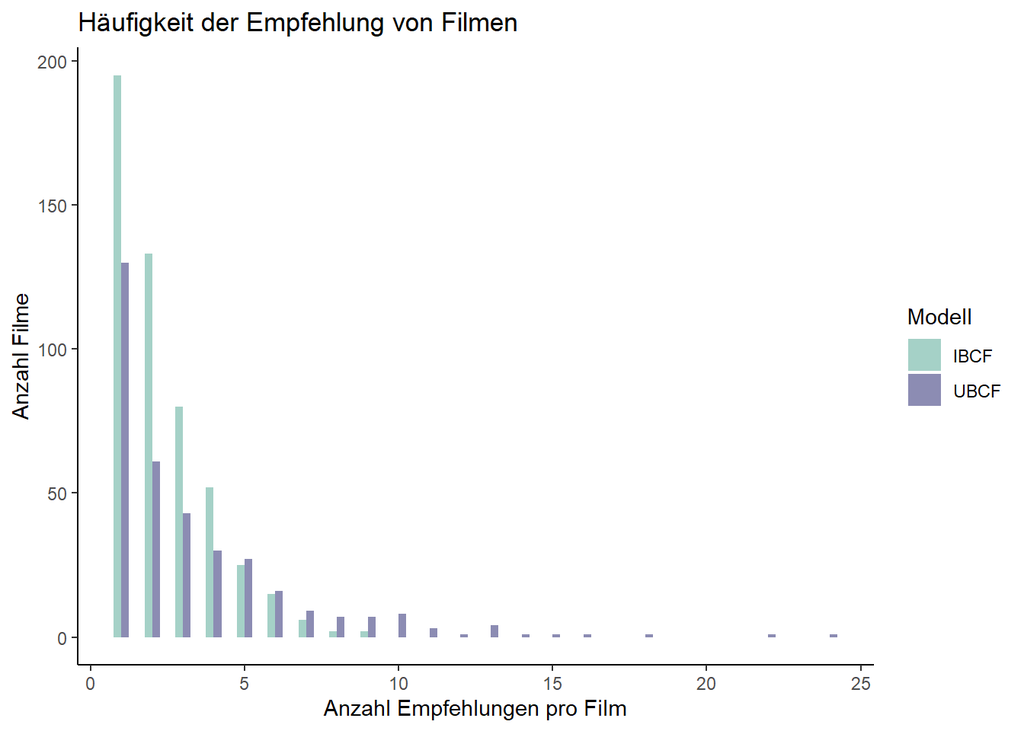

```r
ggplot(moviesUIBCF1, aes(Freq, fill = type)) +
  geom_histogram(alpha = 0.6, position = "dodge", binwidth = 0.5) +
  scale_fill_manual(values = c("#69b3a2", "#404080")) +
  labs(
    title = "Häufigkeit der Empfehlung von Filmen",
    x = "Anzahl Empfehlungen pro Film",
    y = "Anzahl Filme",
    fill = "Modell"
  ) +
  theme_classic()
```

### 6.2.2 Sample 2

```r
freq_pred_UBCF2$type <- "UBCF"
freq_pred_IBCF2$type <- "IBCF"

moviesUIBCF2 <- rbind(freq_pred_UBCF2, freq_pred_IBCF2)
```

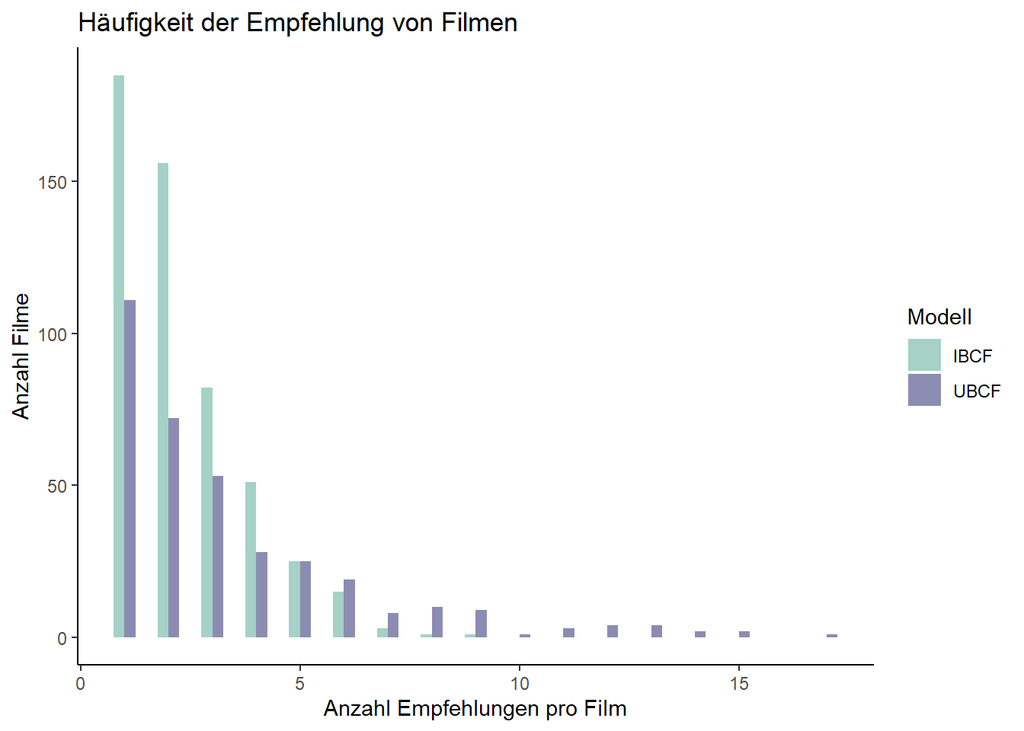

```r
ggplot(moviesUIBCF2, aes(Freq, fill = type)) +
  geom_histogram(alpha = 0.6, position = "dodge", binwidth = 0.5) +
  scale_fill_manual(values = c("#69b3a2", "#404080")) +
  labs(
    title = "Häufigkeit der Empfehlung von Filmen",
    x = "Anzahl Empfehlungen pro Film",
    y = "Anzahl Filme",
    fill = "Modell"
  ) +
  theme_classic()
```

**Beschreibung:** Hier wird visualisiert, wie oft Filme bei IBCF und UBCF empfohlen werden. Auf der x-Achse befindet sich die Anzahl Empfehlungen pro Film und auf der y-Achse wieviele oft die anzahl Empfehlungen pro Film gleich sind. Der ICBF Recommender empfiehlt, dabei merh unterschiedliche Filme als der UBCF recommender. Der UCBF Recommender empfiehlt bis zu 24 mal den gleichen Film.

**Schlussfolgerung:** Die Hypothese wurde wiederlegt, da diverse Filme nur einmal vorgeschlagen werden. Zudem werden keine Filme mehr als 24 mal vorgeschlagen.

# 7 Analyse Top-N Listen - Ratings

Funktion um die Überschneidungen zu berechnen.

```r
intersection_Top15 <- function(prediction1, prediction2,Model1, Model2,Datensatz,return_plot = FALSE) {
   predTopN1 <- as.data.frame(as(prediction1, "matrix"))
  predTopN1$user <- rownames(predTopN1)
  predTopN1 <- pivot_longer(predTopN1, cols = -c(user), values_drop_na = TRUE)

  predTopN2 <- as.data.frame(as(prediction2, "matrix"))
predTopN2$user <- rownames(predTopN2)
predTopN2 <- pivot_longer(predTopN2, cols = -c(user), values_drop_na = TRUE)


intersect <- left_join(predTopN1, predTopN2, by = c("user", "name"))

# count intersect
plot <- intersect %>%
  select(user, value.y) %>%
  group_by(user) %>%
  summarise(total_intersect = sum(!is.na(value.y))) %>%
  ggplot(aes(total_intersect)) +
  geom_histogram(binwidth = 0.5)+
  labs(
    title = "Überschneidungen von Top-15 listen",
    x = "Anzahl Überschneidungen der Bewertungen",
    y = "Anzahl User",
    subtitle = paste(Model1,"und",Model2),
    caption =  paste("Datensatz",Datensatz)) +
  scale_x_continuous(breaks = function(x) unique(floor(pretty(seq(0, (max(x) + 1) * 1.1))))) + # integer on x_axis
  theme_classic() +
  theme(legend.position = "none")
if (return_plot) {
return(plot)
} else {
print(plot)
}
}
```

## 7.1 IBCF vs UBCF, beide mit ordinalem Rating und Cosine Similarity für alle Testkunden

**Hypothese:** Basierend auf der vorherigen Aufgabe, gehen wir davon aus, dass die Anzahl übereinstimmenden Filme relativ klein ist. Da die Verteilungen bei der Aufgabe 5 unterschiedlich sind.

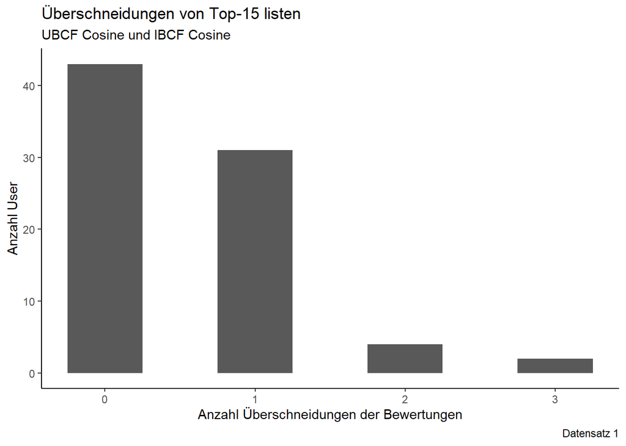

```r
intersection_Top15(pUBCF1,pIBCF1,"UBCF Cosine","IBCF Cosine","1")
```

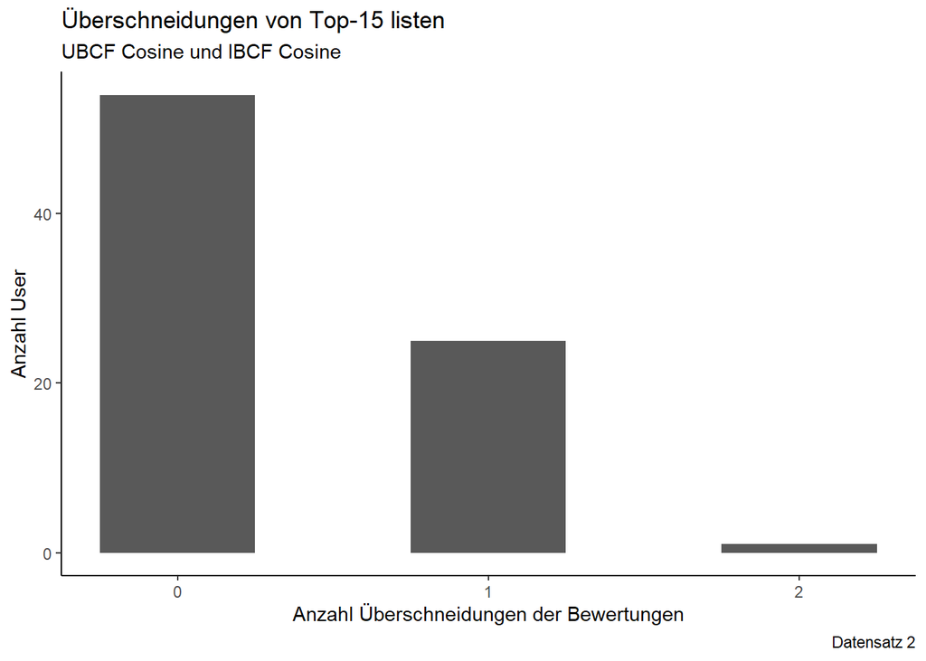

```r
intersection_Top15(pUBCF2,pIBCF2,"UBCF Cosine","IBCF Cosine","2")
```

**Beschreibung:** Die Überschneidung der Daten ist niedrig. Die Meisten Kunden haben keine Überschneidung.

**Schlussfolgerung:** Da der Algorithmus unterschiedlich ist und es diverse mögliche Filme zur Auswahl hat, sind die Top-N listen unterschiedlich.

## 7.2 IBCF vs UBCF, beide mit binärem Rating und Jaccard Similarity für alle Testkunden

**Hypothese:** Die Überschneidung ist grösser wie bei der Cosine Similarity. Trotzdem werden den meisten User unterschiedliche Filme vorgeschlagen.

```r
# Sample 1
# Create binary training and test data
training_binary1 <- training1 > 0
training_binary1[is.na(training_binary1)] <- 0

test_binary1 <- test1 > 0
test_binary1[is.na(test_binary1)] <- 0
```

```r
# Sample 2
# Create binary training and test data
training_binary2 <- training2 > 0
training_binary2[is.na(training_binary2)] <- 0

test_binary2 <- test2 > 0
test_binary2[is.na(test_binary2)] <- 0
```

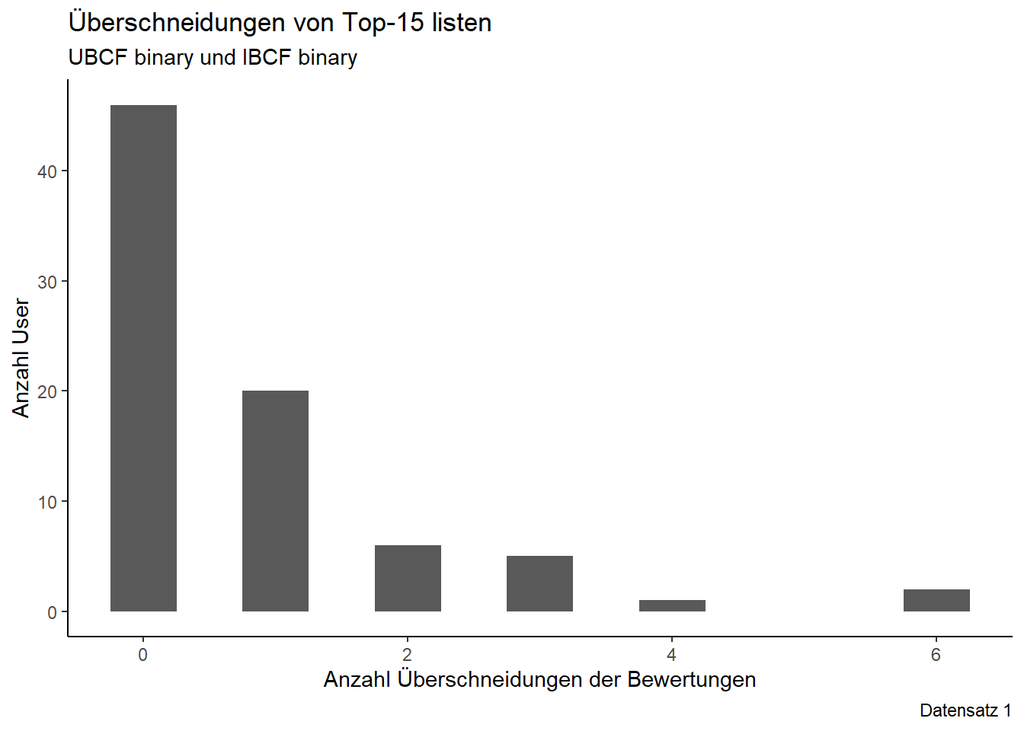

```r
# sample 1
# Train and test binary UBCF-recommender
UBCF_binary1 <- Recommender(as(training_binary1, "realRatingMatrix"), "UBCF", param = list(normalize = NULL, method = "jaccard"))
pUBCF_binary1 <- predict(UBCF_binary1, as(test1, "realRatingMatrix"), type = "topNList", n = 15)

# Train and test binary IBCF-recommender
IBCF_binary1 <- Recommender(as(training_binary1, "realRatingMatrix"), "IBCF", param = list(normalize = NULL, method = "jaccard"))
pIBCF_binary1 <- predict(IBCF_binary1, as(test1, "realRatingMatrix"), type = "topNList", n = 15)
#calculate and plot intersection
intersection_Top15(pUBCF_binary1,pIBCF_binary1,"UBCF binary","IBCF binary","1")
```

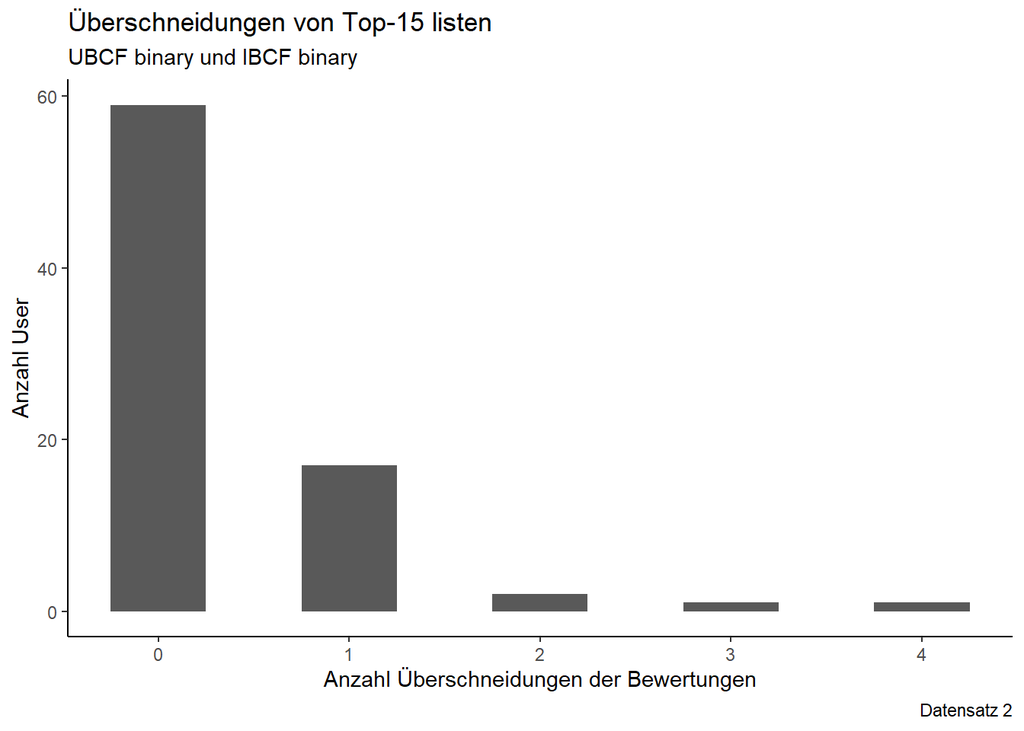

```r
# sample 2
# Train and test binary UBCF-recommender
UBCF_binary2 <- Recommender(as(training_binary2, "realRatingMatrix"), "UBCF", param = list(normalize = NULL, method = "jaccard"))
pUBCF_binary2 <- predict(UBCF_binary2, as(test2, "realRatingMatrix"), type = "topNList", n = 15)

# Train and test binary IBCF-recommender
IBCF_binary2 <- Recommender(as(training_binary2, "realRatingMatrix"), "UBCF", param = list(normalize = NULL, method = "jaccard"))
pIBCF_binary2 <- predict(IBCF_binary1, as(test2, "realRatingMatrix"), type = "topNList", n = 15)

#calculate and plot intersection
intersection_Top15(pUBCF_binary2,pIBCF_binary2,"UBCF binary","IBCF binary","2")
```

**Beschreibung:** Bei den meisten Usern gibt es keine Überschneidung, bei den unterschiedlichen Recommender. Bei diesen Algorithm gibt es User mit 6 Überschneidungen.